# O.4 Frontiers OXT

OXT and Psichological variables - By Gender

Claudiu Papasteri

02 12 2019

# 1 Read and Merge

```r
#~~~~~~~~~~~~~~~~~~~~~~~~~~~~~~~~~~~~~~~~~~~~~~~~~~~~~~~~~~~~~~~~~~~~~~~~~~~~~~~~~~~~~~~~~~~~~~~~~~~~~~~~~~~~~~~~~~~~~~~~~~~~~~~~~~~~~~~~~~
# Read
#~~~~~~~~~~~~~~~~~~~~~~~~~~~~~~~~~~~~~~~~~~~~~~~~~~~~~~~~~~~~~~~~~~~~~~~~~~~~~~~~~~~~~~~~~~~~~~~~~~~~~~~~~~~~~~~~~~~~~~~~~~~~~~~~~~~~~~~~~~
wd <- "C:/Users/Mihai/Desktop/O.4 prealabil pt Frontiers/O.4 Date Psiho&OXT"
setwd(wd)

Data_OXT <- rio::import(file.path(wd, "\\OXT", "O.4 OXT Data.xlsx"))

Data_psih <- rio::import(file.path(wd, "\\Psiho", "DATE O4Cl 16.11.2019 procesat.xlsx"), which = "26martie2019")
Data_psih <- Data_psih[, c(1:6, 8:13)]

Data_Neo <- rio::import(file.path(wd, "\\Psiho", "DATE O4Cl 16.11.2019 procesat.xlsx"), which = "Neo scored")
Data_BDI <- rio::import(file.path(wd, "\\Psiho", "DATE O4Cl 16.11.2019 procesat.xlsx"), which = "BDI scored")
Data_STAI <- rio::import(file.path(wd, "\\Psiho", "DATE O4Cl 16.11.2019 procesat.xlsx"), which = "STAI scored")
```

```r
#~~~~~~~~~~~~~~~~~~~~~~~~~~~~~~~~~~~~~~~~~~~~~~~~~~~~~~~~~~~~~~~~~~~~~~~~~~~~~~~~~~~~~~~~~~~~~~~~~~~~~~~~~~~~~~~~~~~~~~~~~~~~~~~~~~~~~~~~~~
# Clean & Merge
#~~~~~~~~~~~~~~~~~~~~~~~~~~~~~~~~~~~~~~~~~~~~~~~~~~~~~~~~~~~~~~~~~~~~~~~~~~~~~~~~~~~~~~~~~~~~~~~~~~~~~~~~~~~~~~~~~~~~~~~~~~~~~~~~~~~~~~~~~~
Data_STAI <-
  Data_STAI %>%
  dplyr::filter(!is.na(ID)) %>%                                                                # no ID, no data
  dplyr::filter(rowSums(is.na(.)) < 2) %>%                                                     # filter out rows (no more than 1 NA on row)
  mutate(ID = stringr::str_replace(ID, "\\s", "|")) %>%                                        # replace first whitespace with | and use it to separate
  tidyr::separate(ID, into = c("ID", "Experim"), sep = "\\|") %>%                              # separate on only first whitespace that was replaced
  dplyr::select(-Experim)

Data_BDI <-
  Data_BDI %>%
  dplyr::filter(!is.na(ID)) %>%                                                                # no ID, no data
  dplyr::filter(rowSums(is.na(.)) < 1) %>%                                                     # filter out rows (not 1 NA)
  mutate(ID = stringr::str_replace(ID, "\\s", "|")) %>%                                        # replace first whitespace with | and use it to separate
  tidyr::separate(ID, into = c("ID", "Experim"), sep = "\\|") %>%                              # separate on only first whitespace that was replaced
  dplyr::select(-Experim)

Data_Neo <-
  Data_Neo %>%
  dplyr::filter(!is.na(ID)) %>%                                                                # no ID, no data
  dplyr::filter(rowSums(is.na(.)) < 6) %>%                                                     # filter out rows (no more than 5 NA on row)
  mutate(ID = stringr::str_replace(ID, "\\s", "|")) %>%                                        # replace first whitespace with | and use it to separate
  tidyr::separate(ID, into = c("ID", "Experim"), sep = "\\|") %>%                              # separate on only first whitespace that was replaced
  dplyr::select(-Experim)

Data_psih <-
  Data_psih %>%
  dplyr::filter(!is.na(ID)) %>%                                                                # no ID, no data
  dplyr::filter(rowSums(is.na(.)) < 8) %>%                                                     # filter out rows (no more than 7 NA on row)
  tidyr::separate(Conditia,  c("Nr_zi", "Conditia"), "\\s+") %>%                               # split on white space
  mutate(ID = stringr::str_replace(ID, "\\s", "|")) %>%                                        # replace first whitespace with | and use it to separate
  tidyr::separate(ID, into = c("ID", "Experim"), sep = "\\|") %>%                              # separate on only first whitespace that was replaced
  dplyr::rename("Nume" = Nume_Prenume) %>%
  dplyr::select(-Experim)

Data_OXT <-
  Data_OXT %>%
  tidyr::separate(ID,  c("ID", "Ziua", "Nr_zi", "Proba"), "\\s+") %>%                          # split on white space
  select(ID, Nr_zi, Proba, OXT) %>%
  tidyr::separate(ID, into = c("ID", "Experim"), sep = "\\/") %>%                              # separate on /
  dplyr::select(-Experim) %>%
  dplyr::rename("PrePost" = Proba) %>%
  mutate(PrePost = forcats::fct_recode(PrePost, "Pre" = "A", "Post" = "B")) %>%                # Proba A = Pre, B = Post on same day
  spread(key = PrePost, value = OXT) %>%
  dplyr::rename_at(vars(Pre, Post), ~ c("OXT_Pre", "OXT_Post"))


Data_merged <- dplyr::left_join(Data_psih, Data_OXT, by = c("ID", "Nr_zi"))                 # ID 40, 59 are incomplete in OXT -- dplyr::full_join


#~~~~~~~~~~~~~~~~~~~~~~~~~~~~~~~~~~~~~~~~~~~~~~~~~~~~~~~~~~~~~~~~~~~~~~~~~~~~~~~~~~~~~~~~~~~~~~~~~~~~~~~~~~~~~~~~~~~~~~~~~~~~~~~~~~~~~~~~~~
# Make Wide Dataframe of merged
#~~~~~~~~~~~~~~~~~~~~~~~~~~~~~~~~~~~~~~~~~~~~~~~~~~~~~~~~~~~~~~~~~~~~~~~~~~~~~~~~~~~~~~~~~~~~~~~~~~~~~~~~~~~~~~~~~~~~~~~~~~~~~~~~~~~~~~~~~~
# Check if ids have > 1 row of data (empty ID have only 1 row; thei have only 1 Condition)
# Careful! This function modfies the datasets in the global envinronment
delete_empty_id <- function(df){
  list_empty_id <-
    df %>%
    dplyr::group_by(ID) %>%
    dplyr::summarise(row_count = n()) %>%
    dplyr::rename("empty_id" = ID) %>%
    mutate(delete_id = if_else(row_count < 2, TRUE, FALSE)) %>%
    filter(delete_id == TRUE)

  df_modif <-
    df %>%
    filter(!ID %in% list_empty_id$empty_id)

  if(!identical(df, df_modif)){
    df <- deparse(substitute(df))
    cat("Deleting from ", print(as.name(df))); print(list_empty_id)                    # print out which ids are deleted from which dataset
    assign(df, df_modif, envir = globalenv())                                          # assign modified df to original dataset from Global
  }else cat("No empty datasets. Nothing to delete")
}
delete_empty_id(Data_merged)
```

Data_merged Deleting from Data_merged

| empty_id | row_count | delete_id |
| --- | --- | --- |
| 15 | 1 | TRUE |
| 36 | 1 | TRUE |
| 40 | 1 | TRUE |
| 46 | 1 | TRUE |
| 53 | 1 | TRUE |
| 59 | 1 | TRUE |
| 60 | 1 | TRUE |
| 62 | 1 | TRUE |
| 67 | 1 | TRUE |

```r
# Dataframe for regular analyses
Data_merged_wide <-
  Data_merged %>%
  select(-c(Varsta, Gen)) %>%            # exclude Gen, Varsta: merge after because it interferes with spread()
  gather("variable", "value", c(Data, Nr_zi, Vas_Stres_Pre:OXT_Post), -c(1:2)) %>%       # Conditia needs to be outside
  unite("united_var", c(variable, Conditia), sep = "_") %>%
  spread(united_var, value) %>%
  mutate_at(vars(5:22), list(~as.numeric(as.character(.))))

# sum(is.na(Data_merged[, 6:15])) == sum(is.na(Data_merged_wide[, 5:22]))    # check if nr of NA is the same after melt


# Full Wide Dataframe  (HERE We APPLY EXCLUSION CRITERIA)
Data_merged_wide_all <-
  Data_merged[, c("ID", "Nume", "Varsta", "Gen")] %>%                        # need to add these back, but just the main unduplicated row
  dplyr::distinct(ID, .keep_all = TRUE) %>%
    dplyr::left_join(., Data_merged_wide, by = "ID") %>%
    dplyr::rename("Nume" = Nume.x) %>%
    dplyr::select(-Nume.y) %>%
    dplyr::left_join(., Data_BDI, by = "ID") %>%
    dplyr::left_join(., Data_STAI, by = "ID") %>%
    dplyr::left_join(., Data_Neo, by = "ID") %>%
    mutate_at(vars(23:60), list(~as.numeric(as.character(.)))) %>%
    mutate(Varsta = as.numeric(as.character(Varsta))) %>%
    filter(!ID %in% c(19, 43)) %>%           # 55 subs remain after this
    filter(Varsta < 40) %>%                  # 53 subs remain after this
    filter(ScorBDI < 30) %>%                 # 50 subs remain after this
    dplyr::arrange(ID)


# Full Long Dataframe
vars_OglEcran <- grep("OGL|ECRAN", colnames(Data_merged_wide_all))

Data_merged_long_all <-
  Data_merged_wide_all %>%
  gather(variable, value, vars_OglEcran, -c(ID)) %>%                                      # gather Data and Nr_zi as these are OglEcran level
  tidyr::separate(variable,  c("variable", "OglEcran"), "_(?=[^_]+$)") %>%                # split only on last "_"
  spread(variable, value) %>%
  rename_at(vars(vars_OglEcran), list(~stringr::str_remove_all(., c("_OGL|_ECRAN")))) %>%
  arrange(ID)

vars_PrePost <- grep("Pre|Post", colnames(Data_merged_long_all))

Data_merged_long_all <-
  Data_merged_long_all %>%
  pivot_longer(vars_PrePost, names_to = c(".value","PrePost"), names_pattern = "(.*)_(.*)") %>%     # magic
  mutate_at(vars(48:50), list(~as.numeric(as.character(.)))) %>%
  arrange(ID)


# Females and Males Dataframes
Data_fem <-
  Data_merged_wide_all %>%
  filter(Gen == "f")
Data_masc <-
  Data_merged_wide_all %>%
  filter(Gen == "m")

# Difference Scores Dataframe
Data_difscores <-
  Data_merged_wide_all %>%
  mutate(Diff_OXT_OGL = OXT_Post_OGL - OXT_Pre_OGL,
         Diff_OXT_ECRAN = OXT_Post_ECRAN - OXT_Pre_ECRAN,
         Diff_Vas_Stres_OGL = Vas_Stres_Post_OGL - Vas_Stres_Pre_OGL,
         Diff_Vas_Stres_ECRAN = Vas_Stres_Post_ECRAN - Vas_Stres_Pre_ECRAN,
         Diff_Vas_Bine_OGL = Vas_Bine_Post_OGL - Vas_Bine_Pre_OGL,
         Diff_Vas_Bine_ECRAN = Vas_Bine_Post_ECRAN - Vas_Bine_Pre_ECRAN,
         Diff_IOS_OGL = IOS_Post_OGL - IOS_Pre_OGL,
         Diff_IOS_ECRAN = IOS_Post_ECRAN - IOS_Pre_ECRAN
  )
```

## 1.1 Dataset - Long Format

```r
Data_merged_long_all %>%
  dplyr::select(-Nume) %>%
    DT::datatable(
      extensions = 'Buttons',
      options = list(pageLength = 10,
                     scrollX='500px',
                     dom = 'Bfrtip',
                     buttons = c('excel', "csv")))
```

|  | ID | Varsta | Gen | ScorBDI | StaiSbrut | StaiTbrut | N | E | O | A | C | N1 | E1 | O1 | A1 | C1 | N2 | E2 | O2 | A2 | C2 | N3 | E3 | O3 | A3 | C3 | N4 | E4 | O4 | … |
| --- | --- | --- | --- | --- | --- | --- | --- | --- | --- | --- | --- | --- | --- | --- | --- | --- | --- | --- | --- | --- | --- | --- | --- | --- | --- | --- | --- | --- | --- | --- |
| 1 | 10 | 23 | m | 7 | 36 | 36 |  |  |  |  |  |  |  |  |  |  |  |  |  |  |  |  |  |  |  |  |  |  |  | … |
| 2 | 10 | 23 | m | 7 | 36 | 36 |  |  |  |  |  |  |  |  |  |  |  |  |  |  |  |  |  |  |  |  |  |  |  | … |
| 3 | 10 | 23 | m | 7 | 36 | 36 |  |  |  |  |  |  |  |  |  |  |  |  |  |  |  |  |  |  |  |  |  |  |  | … |
| 4 | 10 | 23 | m | 7 | 36 | 36 |  |  |  |  |  |  |  |  |  |  |  |  |  |  |  |  |  |  |  |  |  |  |  | … |
| 5 | 11 | 31 | m | 22 | 57 | 59 |  |  |  |  |  |  |  |  |  |  |  |  |  |  |  |  |  |  |  |  |  |  |  | … |
| 6 | 11 | 31 | m | 22 | 57 | 59 |  |  |  |  |  |  |  |  |  |  |  |  |  |  |  |  |  |  |  |  |  |  |  | … |
| 7 | 11 | 31 | m | 22 | 57 | 59 |  |  |  |  |  |  |  |  |  |  |  |  |  |  |  |  |  |  |  |  |  |  |  | … |
| 8 | 11 | 31 | m | 22 | 57 | 59 |  |  |  |  |  |  |  |  |  |  |  |  |  |  |  |  |  |  |  |  |  |  |  | … |
| 9 | 12 | 24 | f | 1 | 24 | 37 | 143 | 54 | 176 | 140 | 48 | 27 | 14 | 31 | 20 | 15 | 6 | 2 | 31 | 26 | 3 | 28 | 4 | 31 | 26 | 19 | 24 | 8 | 22 | … |
| 10 | 12 | 24 | f | 1 | 24 | 37 | 143 | 54 | 176 | 140 | 48 | 27 | 14 | 31 | 20 | 15 | 6 | 2 | 31 | 26 | 3 | 28 | 4 | 31 | 26 | 19 | 24 | 8 | 22 | … |

[output cut: 190 more lines]

## 1.2 Dataset - Wide Format

```r
Data_merged_wide_all %>%
  dplyr::select(-Nume) %>%
    DT::datatable(
      extensions = 'Buttons',
      options = list(pageLength = 10,
                     scrollX='500px',
                     dom = 'Bfrtip',
                     buttons = c('excel', "csv")))
```

|  | ID | Varsta | Gen | Data_ECRAN | Data_OGL | IOS_Post_ECRAN | IOS_Post_OGL | IOS_Pre_ECRAN | IOS_Pre_OGL | Nr_zi_ECRAN | Nr_zi_OGL | OXT_Post_ECRAN | OXT_Post_OGL | OXT_Pre_ECRAN | OXT_Pre_OGL | Vas_Bine_Post_ECRAN | Vas_Bine_Post_OGL | Vas_Bine_Pre_ECRAN | Vas_Bine_Pre_OGL | Vas_Stres_Post_ECRAN | Vas_Stres_Post_OGL | Vas_Stres_Pre_ECRAN | Vas_Stres_Pre_OGL | ScorBDI | StaiSbrut | StaiTbrut | N | E | O | … |
| --- | --- | --- | --- | --- | --- | --- | --- | --- | --- | --- | --- | --- | --- | --- | --- | --- | --- | --- | --- | --- | --- | --- | --- | --- | --- | --- | --- | --- | --- | --- |
| 1 | 10 | 23 | m | 01.04.2019 | 29.03.2019 |  | 7 |  | 3 | 2 | 1 | 1.3968694273826 | 0.799543118218161 | 1.19248628113128 | 0.726244170934944 | 73 | 84 | 70 | 63 | 25 | 12 | 4 | 31 | 7 | 36 | 36 |  |  |  | … |
| 2 | 11 | 31 | m | 08.04.2019 | 09.04.2019 |  | 3 |  | 2 | 1 | 2 | 1.44098109351048 | 0.836960160696351 | 1.01175268267757 | 1.26415857605178 | 50 | 40 | 50 | 46 | 50 | 45 | 40 | 50 | 22 | 57 | 59 |  |  |  | … |
| 3 | 12 | 24 | f | 09.04.2019 | 16.04.2019 |  | 2 |  | 2 | 1 | 2 | 1.99568500539374 | 1.75138016371597 | 2.35250186706497 | 1.27070245573958 | 97 | 89 | 88 | 71 | 4 | 4 | 7 | 3 | 1 | 24 | 37 | 143 | 54 | 176 | … |
| 4 | 14 | 20 | m | 12.04.2019 | 30.05.2019 |  | 3 |  | 2 | 1 | 2 | 1.1392906677234 | 1.11099989990992 | 1.43319463707813 | 1.07307102708227 | 81 | 46 | 72 | 54 | 4 | 35 | 7 | 23 | 10 | 32 | 42 | 89 | 124 | 125 | … |
| 5 | 16 | 36 | f | 09.05.2019 | 15.04.2019 |  | 4 |  | 3 | 2 | 1 | 1.52373247033441 | 1.70638423065608 | 2.11974110032362 | 1.45631067961165 | 52 | 62 | 62 | 59 | 28 | 26 | 23 | 30 | 4 | 40 | 40 | 90 | 96 | 130 | … |
| 6 | 17 | 22 | f | 17.04.2019 | 23.04.2019 |  | 2 |  | 2 | 1 | 2 | 1.21951219512195 | 1.45631067961165 | 1.17891816920943 | 1.1866235167206 | 73 | 91 | 75 | 90 | 6 | 5 | 9 | 5 | 11 | 43 | 44 | 112 | 97 | 132 | … |
| 7 | 18 | 24 | m | 02.07.2019 | 22.04.2019 | 6 | 4 | 4 | 2 | 2 | 1 | 1.03284445362528 | 1.276910088645 | 0.960654062340317 | 1.09583773911372 | 75 | 83 | 70 | 69 | 27 | 59 | 43 | 69 | 11 | 41 | 56 | 115 | 107 | 159 | … |
| 8 | 20 | 22 | f | 20.06.2019 | 23.05.2019 | 4 | 2 | 4 | 2 | 2 | 1 | 1.4738565914142 | 1.69902912621359 | 1.21951219512195 | 2.19820479941381 | 48 | 70 | 49 | 52 | 65 | 28 | 68 | 61 | 11 | 35 | 42 | 71 | 96 | 124 | … |
| 9 | 22 | 28 | f | 13.06.2019 | 10.06.2019 |  | 3 |  | 2 | 2 | 1 | 2.04962243797195 | 1.35922330097087 | 1.91140776699029 | 1.43457469931894 | 93 | 96 | 91 | 90 | 4 | 5 | 15 | 8 | 3 | 30 | 41 | 124 | 123 | 162 | … |
| 10 | 23 | 28 | m | 11.06.2019 | 21.06.2019 |  | 2 |  | 1 | 1 | 2 | 1.0160307067058 | 1.00940052396363 | 0.935245390576289 | 1.13826581854704 | 83 | 88 | 81 | 84 | 5 | 3 | 14 | 5 | 3 | 23 | 29 | 76 | 98 | 147 | … |

[output cut: 40 more lines]

# 2 Descriptives

## 2.1 Descriptives - Gen Varsta

```r
describe(Data_merged_wide_all$Varsta)
```

|  | vars | n | mean | sd | median | trimmed | mad | min | max | range | skew | kurtosis | se |
| --- | --- | --- | --- | --- | --- | --- | --- | --- | --- | --- | --- | --- | --- |
| X1 | 1 | 50 | 25.7 | 5.08 | 24 | 25.12 | 5.93 | 20 | 39 | 19 | 0.75 | -0.37 | 0.72 |

```r
prop.table(table(Data_merged_wide_all$Gen))
```

```
   f    m
0.54 0.46
```

```r
t.test(Data_merged_wide_all$Varsta ~ Data_merged_wide_all$Gen) %>%
  tidy()
```

| estimate | estimate1 | estimate2 | statistic | p.value | parameter | conf.low | conf.high | method | alternative |
| --- | --- | --- | --- | --- | --- | --- | --- | --- | --- |
| -0.5555556 | 25.44444 | 26 | -0.386743 | 0.7006558 | 47.99964 | -3.443829 | 2.332718 | Welch Two Sample t-test | two.sided |

```r
wilcox.test(Data_merged_wide_all$Varsta ~ Data_merged_wide_all$Gen) %>%
  tidy()
```

```
cannot compute exact p-value with ties
```

| statistic | p.value | method | alternative |
| --- | --- | --- | --- |
| 273 | 0.4692946 | Wilcoxon rank sum test with continuity correction | two.sided |

```r
psych::describeBy(Data_merged_wide_all$Varsta, group = Data_merged_wide_all$Gen)
```

```
 Descriptive statistics by group
group: f
```

|  | vars | n | mean | sd | median | trimmed | mad | min | max | range | skew | kurtosis | se |
| --- | --- | --- | --- | --- | --- | --- | --- | --- | --- | --- | --- | --- | --- |
| X1 | 1 | 27 | 25.44 | 5.49 | 24 | 24.96 | 5.93 | 20 | 37 | 17 | 0.74 | -0.87 | 1.06 |

```
------------------------------------------------------------------------------------------------------------
group: m
```

|  | vars | n | mean | sd | median | trimmed | mad | min | max | range | skew | kurtosis | se |
| --- | --- | --- | --- | --- | --- | --- | --- | --- | --- | --- | --- | --- | --- |
| X1 | 1 | 23 | 26 | 4.67 | 25 | 25.63 | 4.45 | 20 | 39 | 19 | 0.76 | 0.32 | 0.97 |

## 2.2 Plots

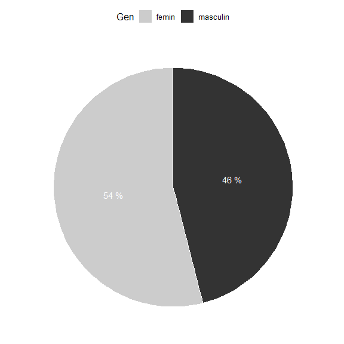

```r
## Pie chart
Data_merged_wide_all  %>%
  mutate(Gen = as.factor(as.character(Gen))) %>%
  mutate(Gen = forcats::fct_recode(Gen, "femin" = "f", "masculin" = "m")) %>%
  group_by(Gen) %>%
  dplyr::summarise(counts = n()) %>%
  mutate(prop = round(counts*100/sum(counts), 1),
         lab.ypos = cumsum(prop) - .5*prop,
         Percent = paste0(prop, " %")) %>%
  ggpubr::ggpie(x = "prop", label = "Percent",
                fill = "Gen", color = "white",
                lab.pos = "in", lab.font = list(color = "white"),
                palette = "grey")
```

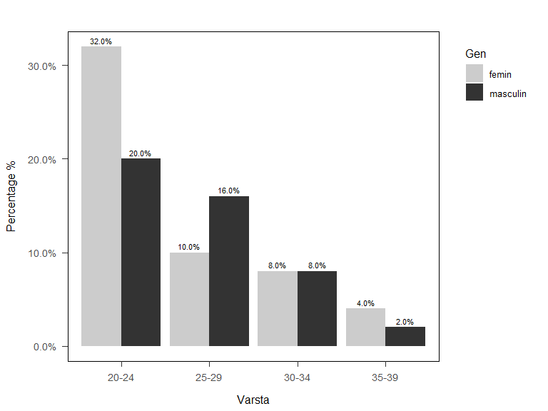

```r
## Dodged Bar plot of Age and Gender
Data_merged_wide_all %>%
  mutate(Varsta = as.numeric(as.character(Varsta))) %>%
  mutate(Varta_categ = cut(Varsta,
                           breaks=c(-Inf, 25, 30, 35, 40),
                           labels=c("20-24","25-29","30-34", "35-39"),
                           right = FALSE)) %>%
  mutate(Varsta = as.factor(Varsta),
         Gen = as.factor(as.character(Gen))) %>%
  mutate(Gen = forcats::fct_recode(Gen, "femin" = "f", "masculin" = "m")) %>%
  dplyr::count(Varta_categ, Gen, .drop = FALSE) %>%         # Group by, then count number in each group (dont drop 0 counts)
  mutate(pct = prop.table(n)) %>%                           # Calculate percent within each var
    ggplot(aes(x = Varta_categ, y = pct, fill = Gen, label = scales::percent(pct))) +
      geom_col(position = position_dodge(preserve = "single"), stat = "identity") +    # Don't drop zero count
      geom_text(position = position_dodge(width = .9),      # move to center of bars
                vjust = -0.5,                               # nudge above top of bar
                size = 3) +
      scale_y_continuous(labels = scales::percent) +
      ggtitle("") +
      xlab("Varsta") + ylab("Percentage %") +
      guides(fill = guide_legend(title = "Gen", ncol = 1)) +
      scale_fill_grey(start = 0.8, end = 0.2, na.value = "red", aesthetics = "fill") +
      theme(legend.position = "right", legend.direction = "vertical",
            legend.justification = c(0, 1), panel.border = element_rect(fill = NA, colour = "black"))
```

## 2.3 t test Varsta by Gen

```r
# Gen
Data_merged_wide_all  %>%
  mutate(Gen = as.factor(as.character(Gen))) %>%
  mutate(Gen = forcats::fct_recode(Gen, "femin" = "f", "masculin" = "m")) %>%
  group_by(Gen) %>%
  dplyr::summarise(counts = n())
```

| Gen | counts |
| --- | --- |
| femin | 27 |
| masculin | 23 |

```r
# varsta
Data_merged_wide_all %>%
  mutate(Gen = as.factor(as.character(Gen))) %>%
  mutate(Varsta = as.numeric(as.character(Varsta))) %>%
  tidystats::describe_data(Varsta, na.rm = TRUE)
```

| var | missing | n | M | SD | SE | min | max | range | median | mode | skew | kurtosis |
| --- | --- | --- | --- | --- | --- | --- | --- | --- | --- | --- | --- | --- |
| Varsta | 0 | 50 | 25.7 | 5.083988 | 0.7189845 | 20 | 39 | 19 | 24 | 20 | 0.7697017 | 2.737933 |

```r
# varsta by Gen
Data_merged_wide_all %>%
  mutate(Varsta = as.numeric(as.character(Varsta))) %>%
  dplyr::group_by(Gen) %>%
  tidystats::describe_data(Varsta, na.rm = TRUE) %>%
  knitr::kable(caption = "Varsta by Gen", format = "pandoc", digits = 2)
```

Varsta by Gen

| var | Gen | missing | n | M | SD | SE | min | max | range | median | mode | skew | kurtosis |
| --- | --- | --- | --- | --- | --- | --- | --- | --- | --- | --- | --- | --- | --- |
| Varsta | f | 0 | 27 | 25.44 | 5.49 | 1.06 | 20 | 37 | 17 | 24 | 20 | 0.78 | 2.30 |
| Varsta | m | 0 | 23 | 26.00 | 4.67 | 0.97 | 20 | 39 | 19 | 25 | 23 | 0.81 | 3.62 |

```r
# t test varsta by Gen
Data_merged_wide_all %>%
  mutate(Varsta = as.numeric(as.character(Varsta))) %>%
  t.test(Varsta ~ Gen, data = .) %>%
  tidy()
```

| estimate | estimate1 | estimate2 | statistic | p.value | parameter | conf.low | conf.high | method | alternative |
| --- | --- | --- | --- | --- | --- | --- | --- | --- | --- |
| -0.5555556 | 25.44444 | 26 | -0.386743 | 0.7006558 | 47.99964 | -3.443829 | 2.332718 | Welch Two Sample t-test | two.sided |

# 3 Define Functions

```r
subchunkify <- function(g, fig_height=7, fig_width=5) {        # THIS FUNC CRASHES PANDOC CONVERSION WITH ERROR 99 - DONT USE HERE
  g_deparsed <- paste0(deparse(
    function() {g}
  ), collapse = '')

  sub_chunk <- paste0("
  `","``{r sub_chunk_", floor(runif(1) * 10000), ", fig.height=", fig_height, ", fig.width=", fig_width, ", echo=FALSE}",
  "\n(",
    g_deparsed
    , ")()",
  "\n`","``
  ")

  cat(knitr::knit(text = knitr::knit_expand(text = sub_chunk), quiet = TRUE))
}
```

```r
#~~~~~~~~~~~~~~~~~~~~~~~~~~~~~~~~~~~~~~~~~~~~~~~~~~~~~~~~~~~~~~~~~~~~~~~~~~~~~~~~~~~~~~~~~~~~~~~~~~~~~~~~~~~~~~~~~~~~~~~~~~~~~~~~~~~~~~~~~~
# Define Function for mining correlations
#~~~~~~~~~~~~~~~~~~~~~~~~~~~~~~~~~~~~~~~~~~~~~~~~~~~~~~~~~~~~~~~~~~~~~~~~~~~~~~~~~~~~~~~~~~~~~~~~~~~~~~~~~~~~~~~~~~~~~~~~~~~~~~~~~~~~~~~~~~
## Function for p-value significance -- both for func_ancova_multibox(), Get_Top_Relationships() and Correlations_With_One()
stars_signif <- function(pval) {
  stars = "ns"
  if(pval <= 0.001)
    stars = "***"
  if(pval > 0.001 & pval <= 0.01)
    stars = "**"
  if(pval > 0.01 & pval <= 0.05)
    stars = "*"
  if(pval > 0.05 & pval <= 0.1)
    stars = "."
  stars
}

## Function that returns correlations of all variables in descending order.
# Arg for threshold with default at .3 will keep only correlantions above .3 and below -.3. Also has threshhold for p-value.
Get_Top_Relationships <- function(data_set,
                                  correlation_abs_threshold=0.3,
                                  pvalue_threshold=0.05) {
  require(psych)
  require(dplyr)
  feature_names <- names(data_set)
  # strip var names to index for pair-wise identification
  names(data_set) <- seq(1:ncol(data_set))
  # calculate correlation and significance numbers
  cor_data_df <- psych::corr.test(data_set)
  # apply var names to correlation matrix over index
  rownames(cor_data_df$r) <- feature_names
  colnames(cor_data_df$r) <- feature_names
  # top cor and sig
  relationships_set <- cor_data_df$ci[,c('r','p')]
  # apply var names to data over index pairs
  relationships_set$feature_1 <- feature_names[as.numeric(sapply(strsplit(rownames(relationships_set), "-"), `[`, 1))]
  relationships_set$feature_2 <- feature_names[as.numeric(
    sapply(strsplit(rownames(relationships_set), "-"), `[`, 2))]
  relationships_set <- dplyr::select(relationships_set, feature_1, feature_2, r, p) %>% dplyr::rename(correlation = r, p.value = p)
  # return only the most insteresting relationships
  return(filter(relationships_set, abs(correlation) > correlation_abs_threshold &
                  p.value < pvalue_threshold) %>%
        arrange(p.value) %>%
        mutate(p.signif = sapply(p.value, function(x) stars_signif(x))))
}

## Function that returns all correlation between numeric variables and one specific variable
Correlations_With_One <- function(data_set,
                            variable,
                            correlation_abs_threshold=0.3,
                            pvalue_threshold=0.05) {
  require(psych)
  require(dplyr)
  # use all numeric columns only
  numeric_cols <- unlist(lapply(data_set, is.numeric))
  data_set <- data_set[, numeric_cols]
  # calculate correlation and significance numbers
  cor_data_df <- psych::corr.test(data_set[, names(data_set) != variable], data_set[, variable], minlength = 20, adjust="none")
  # top cor and sig
  relationships_set <- as.data.frame(cbind(cor_data_df$r, cor_data_df$p))     # same as  cor_data_df$ci[,c('r','p')]
  relationships_set <- tibble::rownames_to_column(relationships_set, "Variable")   # relationships_set$Variable <- rownames(relationships_set)
  colnames(relationships_set) <- c("Variable", "correlation", "p.value")
  # return only the most insteresting relationships
  cat("#### Correlations with ", variable, "\n")
  return(filter(relationships_set, abs(correlation) > correlation_abs_threshold &
                  p.value < pvalue_threshold) %>%
           arrange(p.value) %>%
           mutate(p.signif = sapply(p.value, function(x) stars_signif(x)))) %>%
           tibble::as.tibble()
}


## Function for ploting correlation data frames resulting from Get_Top_Relationships and Correlations_With_One()
func_dotplot_cor <- function(df){                                        # https://www.r-pkg.org/pkg/ggpubr
  dotplotcor_scale_fill <- function(...){                                # Fix colors to signif factor levels even if missing
    ggplot2:::manual_scale(
      'color',
      values = setNames(
        c("darkgreen", "green3", "lawngreen", "yellow", "red"),
        c("***", "**", "*", ".", "ns")),
      ...
    )
  }

  dtoplot_theme <-
    ggpubr::theme_pubr() +
    theme(axis.text.y = element_text(size = 10))

  if(!"Variable" %in% colnames(df)){                                             # in oder to work for both Get_Top_Relationships and Correlations_With_One()
  df <-
    df %>%
      unite(cor_between, c("feature_1", "feature_2"), sep = " X ")               # unite 2 columns to x name from plot
  }else df <- df %>% dplyr::rename(cor_between = Variable)                       # change Variable to x name from plot

  df %>%
    ggpubr::ggdotchart(x = "cor_between", y = "correlation",
                       color = "p.signif",                                       # Color by sig
                       #   palette = c("#00AFBB", "#E7B800", "#FC4E07"),         # Custom color palette
                       sorting = "descending",                                   # Sort value in descending order
                       add = "segments",                                         # Add segments from y = 0 to dots
                       add.params = list(color = "lightgray", size = 2),         # Change segment color and size
                       group = "p.signif",                                       # Order by groups
                       dot.size = 8,                                             # Large dot size
                       xlab = "",
                       rotate = TRUE,                                            # Rotate vertically
                       label = round(.$correlation, 1),                          # Add mpg values as dot labels
                       font.label = list(color = "white", size = 9,
                                         vjust = 0.5),                           # Adjust label parameters
                       ggtheme = dtoplot_theme) +                                # ggplot2 theme
    dotplotcor_scale_fill() +                                            # Fix colors to signif factor levels even if missing
    geom_hline(yintercept = 0, linetype = 2, color = "lightgray")
}
```

```r
#~~~~~~~~~~~~~~~~~~~~~~~~~~~~~~~~~~~~~~~~~~~~~~~~~~~~~~~~~~~~~~~~~~~~~~~~~~~~~~~~~~~~~~~~~~~~~~~~~~~~~~~~~~~~~~~~~~~~~~~~~~~~~~~~~~~~~~~~~~
# Define Function for Pre-Post Plots, t Change and ANCOVA Post
#~~~~~~~~~~~~~~~~~~~~~~~~~~~~~~~~~~~~~~~~~~~~~~~~~~~~~~~~~~~~~~~~~~~~~~~~~~~~~~~~~~~~~~~~~~~~~~~~~~~~~~~~~~~~~~~~~~~~~~~~~~~~~~~~~~~~~~~~~~
## Func t test si boxplot simplu
func_t_box <- function(df, ind, pre_var, post_var){
  df_modif <-
    df %>%
    select(ind, pre_var, post_var) %>%
    tidyr::drop_na() %>%
    gather(pre_var, post_var, key = "Cond", value = "value") %>%
    mutate_at(vars(c(1, 2)), list(~as.factor(.))) %>%
    mutate(Cond = factor(Cond, levels = c(pre_var, post_var)))

  stat_comp <- ggpubr::compare_means(value ~ Cond, data = df_modif, method = "t.test", paired = TRUE)

  stat_comp2 <-
    df_modif %>%
    do(tidy(t.test(.$value ~ .$Cond,
                   paired = TRUE,
                   data=.)))

  plot <-
    ggpubr::ggpaired(df_modif, x = "Cond", y = "value", id = ind,
                     color = "Cond", line.color = "gray", line.size = 0.4,
                     palette = c("#00AFBB", "#FC4E07"), legend = "none") +
      stat_summary(fun.data = mean_se,  colour = "darkred") +
      ggpubr::stat_compare_means(method = "t.test", paired = TRUE, label.x = as.numeric(df_modif$Cond)-0.4, label.y = max(df_modif$value)+0.5) +
      ggpubr::stat_compare_means(method = "t.test", paired = TRUE, label = "p.signif", comparisons = list(c(pre_var, post_var)))

  cat(paste0("#### ", pre_var, " ", post_var, "\n", "\n"))
  print(stat_comp)
  print(stat_comp2)
  print(plot)
}


func_ancova_multibox <- function(df, ind, pre_var_c1, post_var_c1, pre_var_c2, post_var_c2){

  diff_score_c1 <- paste0(post_var_c1, " - ", pre_var_c1)
  diff_score_c2 <- paste0(post_var_c2, " - ", pre_var_c2)

  ## Plots and p-values for t tests
  df_modif <-
    df %>%
    select(ind, pre_var_c1, post_var_c1, pre_var_c2, post_var_c2) %>%
    tidyr::drop_na() %>%
    gather(pre_var_c1, post_var_c1, pre_var_c2, post_var_c2, key = "Cond", value = "value") %>%
    mutate_at(vars(c(1, 2)), list(~as.factor(.))) %>%
    mutate(Cond = factor(Cond, levels = c(pre_var_c1, post_var_c1, pre_var_c2, post_var_c2)))

  stat_comp <- ggpubr::compare_means(value ~ Cond, data = df_modif, method = "t.test", paired = TRUE, p.adjust.method = "holm")

  plot <-
    ggpubr::ggpaired(df_modif, x = "Cond", y = "value", id = ind,
                     color = "Cond", line.color = "gray", line.size = 0.4,
                     palette = c("#00AFBB", "#FC4E07", "#00AFBB", "#FC4E07"), legend = "none") +
    stat_summary(fun.data = mean_se,  colour = "darkred") +
    ggpubr::stat_compare_means(method = "t.test", paired = TRUE, label = "p.signif",
                               label.y = c(max(df_modif$value) + 0.1*IQR(df_modif$value),
                                           max(df_modif$value) + 0.1*IQR(df_modif$value),
                                           seq(max(df_modif$value) + 0.3*IQR(df_modif$value),
                                               max(df_modif$value) + 0.9*IQR(df_modif$value), length.out = 4)),
                               comparisons = list(c(pre_var_c1, post_var_c1),
                                                  c(pre_var_c2, post_var_c2),
                                                  c(post_var_c1, pre_var_c2),
                                                  c(pre_var_c1, pre_var_c2),
                                                  c(post_var_c1, post_var_c2),
                                                  c(pre_var_c1, post_var_c2)))

  ## For ttestChange or ANCOVAChange - we do ttestChange (Post-Pre) here, but it isnt very important
  df_modif2 <-
    df %>%
    select(ind, pre_var_c1, post_var_c1, pre_var_c2, post_var_c2) %>%
    tidyr::drop_na()
  df_modif2[diff_score_c1] <- df_modif2[, post_var_c1] - df_modif2[, pre_var_c1]
  df_modif2[diff_score_c2] <- df_modif2[, post_var_c2] - df_modif2[, pre_var_c2]

  tChange <- t.test(df_modif2[, diff_score_c1], df_modif2[, diff_score_c2], paired = TRUE)

  ## For descriptives by 2 factors (PrePost and OglEcran)
  df_modif3 <-
    df %>%
    select(ind, pre_var_c1, post_var_c1, pre_var_c2, post_var_c2) %>%
    tidyr::drop_na() %>%
    gather(pre_var_c1, post_var_c1, pre_var_c2, post_var_c2, key = "Cond", value = "value") %>%
    mutate(PrePost = case_when(stringr::str_detect(.$"Cond", "pre|Pre") ~ "Pre",
                               stringr::str_detect(.$"Cond", "post|Post") ~ "Post",
                               TRUE ~ NA_character_),
           OglEcran = case_when(stringr::str_detect(.$"Cond", "ogl|OGL") ~ "OGL",
                              stringr::str_detect(.$"Cond", "ecran|ECRAN") ~ "ECRAN",
                              TRUE ~ NA_character_)) %>%
    mutate(PrePost = as.factor(PrePost),
           OglEcran = as.factor(OglEcran))

  ## For ANCOVAPost - this is what we use
  df_modif4 <-
    df_modif3 %>%
    select(-"Cond") %>%
    spread("PrePost", "value")

  ## Models (here we use ANCOVAPost)    # https://m-clark.github.io/docs/mixedModels/anovamixed.html#introduction
  full_ancovaPost <-                                          # this is better than using lm() and glht()
      jmv::ancova(
        formula = Post ~ Pre + OglEcran,
        data = df_modif4,
        homo = TRUE,
        ss = "3",
        postHoc = ~ OglEcran,
        postHocCorr = list("tukey"),
        effectSize = list("eta", "partEta")
      )

      # mod_ancovaPost <- lm(Post ~ Pre + OglEcran, data = df_modif4)            # this is a Covariate Second model
      # mod_ancovaPost_ss3 <- car::Anova(mod_ancovaPost, type = "III")         # Type III sums of squares; see Andy Fields 2012
      # postHocs <- multcomp::glht(mod_ancovaPost, linfct = multcomp::mcp(OglEcran = "Tukey"))  # differences between the adjusted means,
      # sum_postHocs <- summary(postHocs)                                               # use Tukey or Dunnett?s post hoc tests
      # conf_postHocs <- confint(postHocs)
  scatter <-                                                             # Check for homogeneity of regression slopes
    ggplot(df_modif4, aes(Pre, Post, colour = OglEcran)) +
    geom_point(aes(shape = OglEcran), size = 3) +
    geom_smooth(method = "lm", aes(fill = OglEcran), alpha = 0.1)


  ## Other Models that work for this date
  # mod_ancovaPost <- lm(post ~ pre + treat)      # exactly the same with aov(post ~ pre + treat)
  # summary(mod_ancovaPost)
  #
  # mod_anovaRM <- aov(score ~ treat*time + Error(id), dflong)
  # summary(mod_anovaRM)
  #
  # mod_lme <- lme4::lmer(score ~ treat*time + (1|id), data=dflong)
  # anova(lmeModel)

  ## Output
  print(plot)
  cat(paste0("#### ", pre_var_c1, " ", post_var_c1, " ", pre_var_c2, " ", post_var_c2, "\n", "\n"))

  cat("#### Descriptives")
  psych::describeBy(df_modif3[, "value"], list(df_modif3[, "PrePost"], df_modif3[, "OglEcran"]), mat = TRUE) %>%
    as.tibble() %>%
    print()
  cat("\n")

  print(stat_comp)
  cat("\n")

  cat("#### t Change")
  tidy(tChange) %>% print()
  cat("\n")

  cat("#### ANCOVA Post")
  cat("\n")
  cat("##### Homogeneity test")
  print(tibble::as.tibble(full_ancovaPost$assump$homo))
  cat("##### ANCOVA output")
  print(tibble::as.tibble(full_ancovaPost$main))
  # tidy(mod_ancovaPost) %>%
  #   mutate(p.signif = sapply(p.value, function(x) stars_signif(x))) %>%
  #   print()
  # cat("\n")
  cat("##### Post Hoc")
  print(tibble::as.tibble(full_ancovaPost$postHoc[[1]]))
  # tidy(sum_postHocs) %>%
  #   mutate(p.signif = sapply(p.value, function(x) stars_signif(x))) %>%
  #   print()
  cat("\n")
  cat("##### Homogeneity of regression slopes")
  # subchunkify(plot(scatter), 5, 5)                       # THIS FUNC CRASHES PANDOC CONVERSION WITH ERROR 99 - DONT USE HERE
}
```

# 4 Analyses

## 4.1 Simple before-after analyses with t test

```r
#~~~~~~~~~~~~~~~~~~~~~~~~~~~~~~~~~~~~~~~~~~~~~~~~~~~~~~~~~~~~~~~~~~~~~~~~~~~~~~~~~~~~~~~~~~~~~~~~~~~~~~~~~~~~~~~~~~~~~~~~~~~~~~~~~~~~~~~~~~
# Simple before-after analyses with t test
#~~~~~~~~~~~~~~~~~~~~~~~~~~~~~~~~~~~~~~~~~~~~~~~~~~~~~~~~~~~~~~~~~~~~~~~~~~~~~~~~~~~~~~~~~~~~~~~~~~~~~~~~~~~~~~~~~~~~~~~~~~~~~~~~~~~~~~~~~~
## OXT has 2 outliers: 19, 43
# func_t_box(Data_merged_wide, "ID", "OXT_Pre_OGL", "OXT_Post_OGL")          # outlier in 57 sub
# func_t_box(Data_merged_wide, "ID", "OXT_Pre_ECRAN", "OXT_Post_ECRAN")      # ns

func_t_box(Data_merged_wide_all, "ID", "OXT_Pre_OGL", "OXT_Post_OGL")    # ns
```

#### 4.1.0.1 OXT_Pre_OGL OXT_Post_OGL

| .y. | group1 | group2 | p | p.adj | p.format | p.signif | method |
| --- | --- | --- | --- | --- | --- | --- | --- |
| value | OXT_Pre_OGL | OXT_Post_OGL | 0.2823666 | 0.28 | 0.28 | ns | T-test |

| estimate | statistic | p.value | parameter | conf.low | conf.high | method | alternative |
| --- | --- | --- | --- | --- | --- | --- | --- |
| -0.05550764 | -1.088049 | 0.2823666 | 45 | -0.1582586 | 0.04724334 | Paired t-test | two.sided |

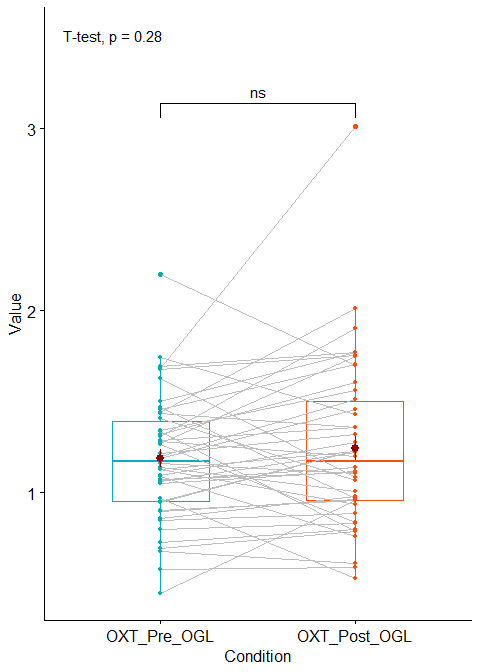

```r
func_t_box(Data_merged_wide_all, "ID", "OXT_Pre_ECRAN", "OXT_Post_ECRAN")   # ns
```

#### 4.1.0.2 OXT_Pre_ECRAN OXT_Post_ECRAN

| .y. | group1 | group2 | p | p.adj | p.format | p.signif | method |
| --- | --- | --- | --- | --- | --- | --- | --- |
| value | OXT_Pre_ECRAN | OXT_Post_ECRAN | 0.09719581 | 0.097 | 0.097 | ns | T-test |

| estimate | statistic | p.value | parameter | conf.low | conf.high | method | alternative |
| --- | --- | --- | --- | --- | --- | --- | --- |
| -0.07332988 | -1.693901 | 0.09719581 | 45 | -0.1605215 | 0.01386171 | Paired t-test | two.sided |

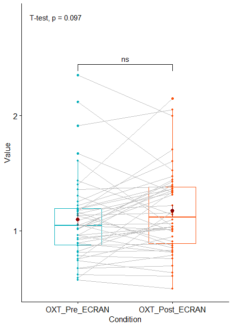

```r
func_t_box(Data_merged_wide_all, "ID", "Vas_Stres_Pre_OGL", "Vas_Stres_Post_OGL")         # sig
```

#### 4.1.0.3 Vas_Stres_Pre_OGL Vas_Stres_Post_OGL

| .y. | group1 | group2 | p | p.adj | p.format | p.signif | method |
| --- | --- | --- | --- | --- | --- | --- | --- |
| value | Vas_Stres_Pre_OGL | Vas_Stres_Post_OGL | 0.006071497 | 0.0061 | 0.0061 | ** | T-test |

| estimate | statistic | p.value | parameter | conf.low | conf.high | method | alternative |
| --- | --- | --- | --- | --- | --- | --- | --- |
| 3.96 | 2.868293 | 0.006071497 | 49 | 1.185556 | 6.734444 | Paired t-test | two.sided |

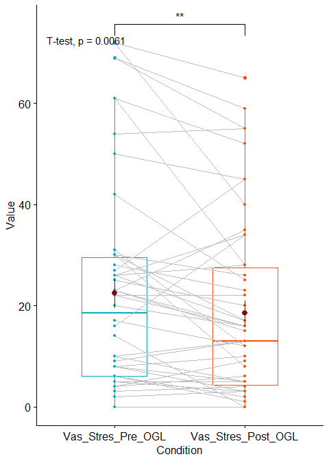

```r
func_t_box(Data_merged_wide_all, "ID", "Vas_Stres_Pre_ECRAN", "Vas_Stres_Post_ECRAN")     # ns
```

#### 4.1.0.4 Vas_Stres_Pre_ECRAN Vas_Stres_Post_ECRAN

| .y. | group1 | group2 | p | p.adj | p.format | p.signif | method |
| --- | --- | --- | --- | --- | --- | --- | --- |
| value | Vas_Stres_Pre_ECRAN | Vas_Stres_Post_ECRAN | 0.06752433 | 0.068 | 0.068 | ns | T-test |

| estimate | statistic | p.value | parameter | conf.low | conf.high | method | alternative |
| --- | --- | --- | --- | --- | --- | --- | --- |
| 2.632653 | 1.870458 | 0.06752433 | 48 | -0.1972982 | 5.462604 | Paired t-test | two.sided |

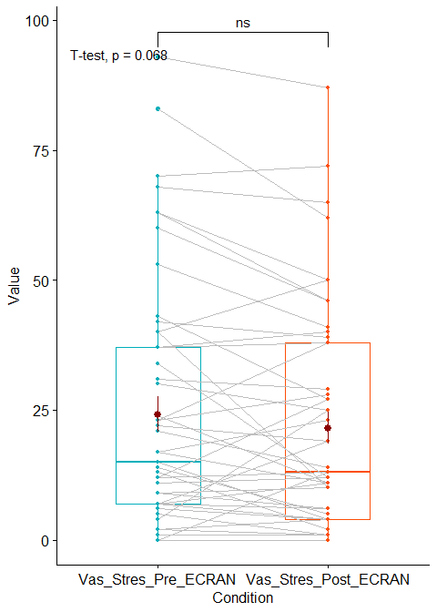

```r
func_t_box(Data_merged_wide_all, "ID", "Vas_Bine_Pre_OGL", "Vas_Bine_Post_OGL")           # ns
```

#### 4.1.0.5 Vas_Bine_Pre_OGL Vas_Bine_Post_OGL

| .y. | group1 | group2 | p | p.adj | p.format | p.signif | method |
| --- | --- | --- | --- | --- | --- | --- | --- |
| value | Vas_Bine_Pre_OGL | Vas_Bine_Post_OGL | 0.1035265 | 0.1 | 0.1 | ns | T-test |

| estimate | statistic | p.value | parameter | conf.low | conf.high | method | alternative |
| --- | --- | --- | --- | --- | --- | --- | --- |
| -2.84 | -1.658889 | 0.1035265 | 49 | -6.280371 | 0.6003706 | Paired t-test | two.sided |

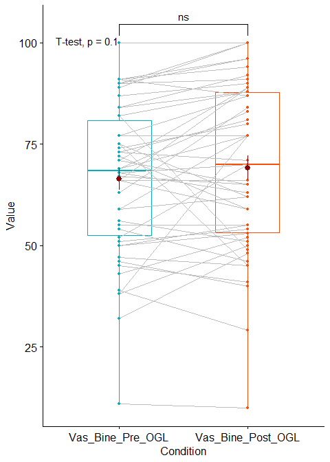

```r
func_t_box(Data_merged_wide_all, "ID", "Vas_Bine_Pre_ECRAN", "Vas_Bine_Post_ECRAN")       # sig
```

#### 4.1.0.6 Vas_Bine_Pre_ECRAN Vas_Bine_Post_ECRAN

| .y. | group1 | group2 | p | p.adj | p.format | p.signif | method |
| --- | --- | --- | --- | --- | --- | --- | --- |
| value | Vas_Bine_Pre_ECRAN | Vas_Bine_Post_ECRAN | 0.02256027 | 0.023 | 0.023 | * | T-test |

| estimate | statistic | p.value | parameter | conf.low | conf.high | method | alternative |
| --- | --- | --- | --- | --- | --- | --- | --- |
| -2.959184 | -2.356815 | 0.02256027 | 48 | -5.483708 | -0.4346591 | Paired t-test | two.sided |

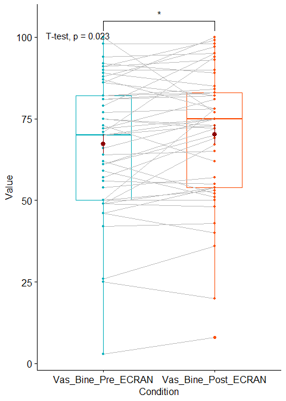

```r
func_t_box(Data_merged_wide_all, "ID", "IOS_Pre_OGL", "IOS_Post_OGL")                     # sig
```

#### 4.1.0.7 IOS_Pre_OGL IOS_Post_OGL

| .y. | group1 | group2 | p | p.adj | p.format | p.signif | method |
| --- | --- | --- | --- | --- | --- | --- | --- |
| value | IOS_Pre_OGL | IOS_Post_OGL | 0.000002558372 | 0.0000026 | 0.0000026 | **** | T-test |

| estimate | statistic | p.value | parameter | conf.low | conf.high | method | alternative |
| --- | --- | --- | --- | --- | --- | --- | --- |
| -0.86 | -5.320147 | 0.000002558372 | 49 | -1.184847 | -0.5351528 | Paired t-test | two.sided |

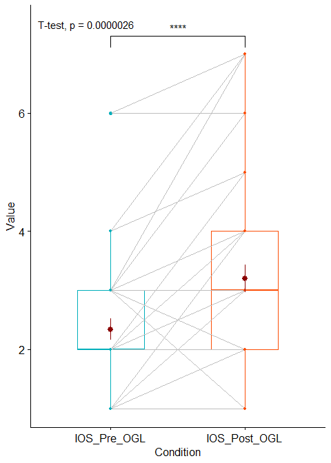

```r
func_t_box(Data_merged_wide_all, "ID", "IOS_Pre_ECRAN", "IOS_Post_ECRAN")                 # ns
```

#### 4.1.0.8 IOS_Pre_ECRAN IOS_Post_ECRAN

| .y. | group1 | group2 | p | p.adj | p.format | p.signif | method |
| --- | --- | --- | --- | --- | --- | --- | --- |
| value | IOS_Pre_ECRAN | IOS_Post_ECRAN | 1 | 1 | 1 | ns | T-test |

| estimate | statistic | p.value | parameter | conf.low | conf.high | method | alternative |
| --- | --- | --- | --- | --- | --- | --- | --- |
| 0 | 0 | 1 | 34 | -0.2040765 | 0.2040765 | Paired t-test | two.sided |

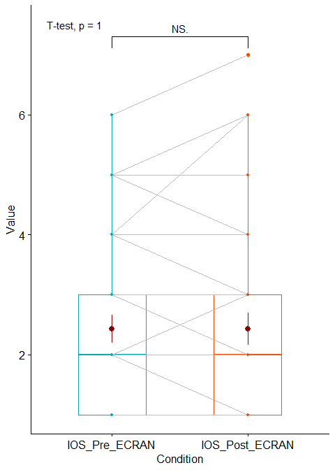

## 4.2 tChance and ANCOVAPost

```r
## tChance and ANCOVAPost

func_ancova_multibox(Data_merged_wide_all, "ID", "OXT_Pre_OGL", "OXT_Post_OGL", "OXT_Pre_ECRAN", "OXT_Post_ECRAN")              # ns
```

#### 4.2.0.1 OXT_Pre_OGL OXT_Post_OGL OXT_Pre_ECRAN OXT_Post_ECRAN

#### 4.2.0.2 Descriptives

| item | group1 | group2 | vars | n | mean | sd | median | trimmed | mad | min | max | range | skew | kurtosis | se |
| --- | --- | --- | --- | --- | --- | --- | --- | --- | --- | --- | --- | --- | --- | --- | --- |
| 1 | Post | ECRAN | 1 | 46 | 1.169902 | 0.3691512 | 1.118380 | 1.144387 | 0.3710008 | 0.4974490 | 2.146657 | 1.649208 | 0.6272752 | 0.1708302 | 0.05442837 |
| 2 | Pre | ECRAN | 1 | 46 | 1.096572 | 0.3738875 | 1.046633 | 1.050955 | 0.2450911 | 0.5716175 | 2.352502 | 1.780884 | 1.3451802 | 2.0798667 | 0.05512671 |
| 3 | Post | OGL | 1 | 46 | 1.243815 | 0.4557335 | 1.171186 | 1.211194 | 0.4011652 | 0.5322802 | 3.009259 | 2.476979 | 1.2588042 | 2.8241855 | 0.06719424 |
| 4 | Pre | OGL | 1 | 46 | 1.188307 | 0.3404891 | 1.172719 | 1.182493 | 0.3312345 | 0.4504145 | 2.198205 | 1.747790 | 0.3204706 | 0.3428848 | 0.05020238 |

NA

| .y. | group1 | group2 | p | p.adj | p.format | p.signif | method |
| --- | --- | --- | --- | --- | --- | --- | --- |
| value | OXT_Pre_OGL | OXT_Post_OGL | 0.28236660 | 0.83 | 0.282 | ns | T-test |
| value | OXT_Pre_OGL | OXT_Pre_ECRAN | 0.13872767 | 0.55 | 0.139 | ns | T-test |
| value | OXT_Pre_OGL | OXT_Post_ECRAN | 0.73508794 | 0.83 | 0.735 | ns | T-test |
| value | OXT_Post_OGL | OXT_Pre_ECRAN | 0.03430070 | 0.21 | 0.034 | * | T-test |
| value | OXT_Post_OGL | OXT_Post_ECRAN | 0.27654276 | 0.83 | 0.277 | ns | T-test |
| value | OXT_Pre_ECRAN | OXT_Post_ECRAN | 0.09719581 | 0.49 | 0.097 | ns | T-test |

#### 4.2.0.3 t Change

| estimate | statistic | p.value | parameter | conf.low | conf.high | method | alternative |
| --- | --- | --- | --- | --- | --- | --- | --- |
| -0.01782224 | -0.2468826 | 0.8061219 | 45 | -0.1632186 | 0.1275741 | Paired t-test | two.sided |

#### 4.2.0.4 ANCOVA Post

##### 4.2.0.4.1 Homogeneity test

| F | df1 | df2 | p |
| --- | --- | --- | --- |
| 0.7993109 | 1 | 90 | 0.3736841 |

##### 4.2.0.4.2 ANCOVA output

| name | ss | df | ms | F | p | etaSq | etaSqP |
| --- | --- | --- | --- | --- | --- | --- | --- |
| Pre | 6.8210348592 | 1 | 6.8210348592 | 70.12160238 | 0.0000000000007396194 | 0.44067238239 | 0.44067933789 |
| OglEcran | 0.0002443094 | 1 | 0.0002443094 | 0.00251155 | 0.9601427580511390225 | 0.00001578359 | 0.00002821886 |
| Residuals | 8.6574191383 | 89 | 0.0972743723 | NA | NA | NA | NA |

##### 4.2.0.4.3 Post Hoc

| OglEcran1 | sep | OglEcran2 | md | se | df | t | ptukey |
| --- | --- | --- | --- | --- | --- | --- | --- |
| ECRAN | - | OGL | -0.003286459 | 0.06557787 | 89 | -0.05011536 | 0.9601428 |

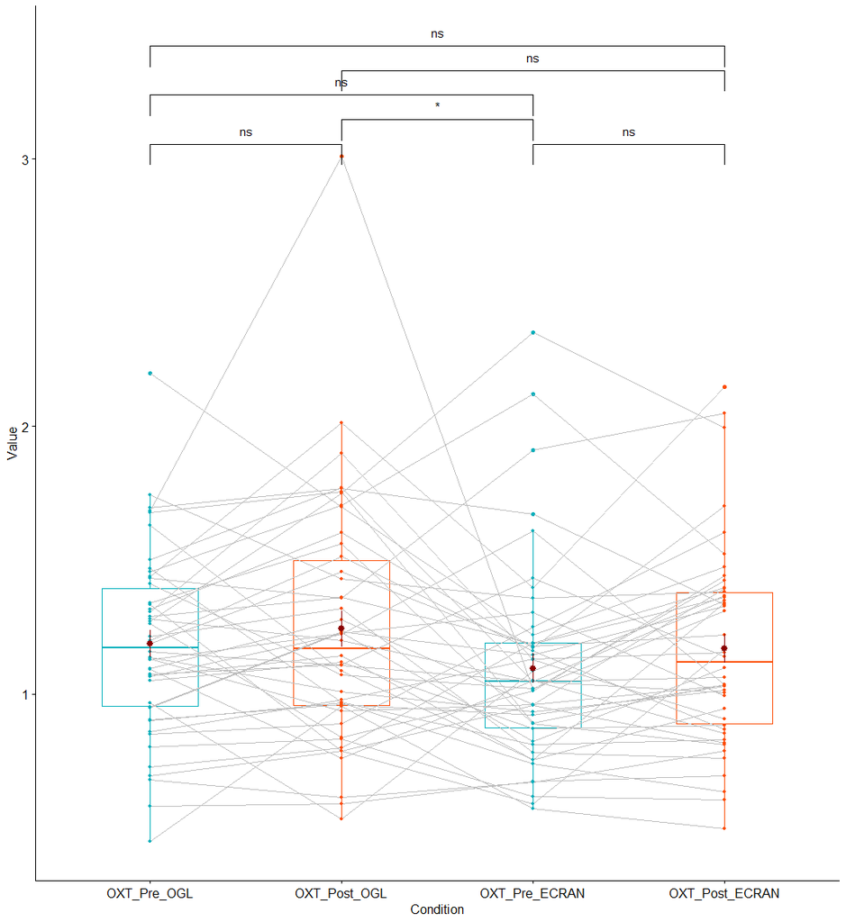

```r
func_ancova_multibox(Data_merged_wide_all,  "ID", "Vas_Stres_Pre_OGL", "Vas_Stres_Post_OGL", "Vas_Stres_Pre_ECRAN", "Vas_Stres_Post_ECRAN")    # ns
```

#### 4.2.0.5 Vas_Stres_Pre_OGL Vas_Stres_Post_OGL Vas_Stres_Pre_ECRAN Vas_Stres_Post_ECRAN

#### 4.2.0.6 Descriptives

| item | group1 | group2 | vars | n | mean | sd | median | trimmed | mad | min | max | range | skew | kurtosis | se |
| --- | --- | --- | --- | --- | --- | --- | --- | --- | --- | --- | --- | --- | --- | --- | --- |
| 1 | Post | ECRAN | 1 | 49 | 21.53061 | 21.49719 | 13 | 18.75610 | 17.7912 | 0 | 87 | 87 | 1.0884051 | 0.45638404 | 3.071027 |
| 2 | Pre | ECRAN | 1 | 49 | 24.16327 | 24.15087 | 15 | 21.21951 | 19.2738 | 0 | 93 | 93 | 1.0740829 | 0.22331823 | 3.450124 |
| 3 | Post | OGL | 1 | 49 | 18.51020 | 18.08328 | 13 | 16.41463 | 14.8260 | 0 | 65 | 65 | 0.9689966 | -0.14823912 | 2.583326 |
| 4 | Pre | OGL | 1 | 49 | 22.28571 | 21.30728 | 17 | 19.75610 | 16.3086 | 0 | 72 | 72 | 1.0476672 | 0.02812125 | 3.043897 |

NA

| .y. | group1 | group2 | p | p.adj | p.format | p.signif | method |
| --- | --- | --- | --- | --- | --- | --- | --- |
| value | Vas_Stres_Pre_OGL | Vas_Stres_Post_OGL | 0.009457767 | 0.057 | 0.0095 | ** | T-test |
| value | Vas_Stres_Pre_OGL | Vas_Stres_Pre_ECRAN | 0.527852557 | 1.000 | 0.5279 | ns | T-test |
| value | Vas_Stres_Pre_OGL | Vas_Stres_Post_ECRAN | 0.787907726 | 1.000 | 0.7879 | ns | T-test |
| value | Vas_Stres_Post_OGL | Vas_Stres_Pre_ECRAN | 0.038459503 | 0.190 | 0.0385 | * | T-test |
| value | Vas_Stres_Post_OGL | Vas_Stres_Post_ECRAN | 0.251888149 | 0.760 | 0.2519 | ns | T-test |
| value | Vas_Stres_Pre_ECRAN | Vas_Stres_Post_ECRAN | 0.067524332 | 0.270 | 0.0675 | ns | T-test |

#### 4.2.0.7 t Change

| estimate | statistic | p.value | parameter | conf.low | conf.high | method | alternative |
| --- | --- | --- | --- | --- | --- | --- | --- |
| -1.142857 | -0.5336299 | 0.5960602 | 48 | -5.448966 | 3.163252 | Paired t-test | two.sided |

#### 4.2.0.8 ANCOVA Post

##### 4.2.0.8.1 Homogeneity test

| F | df1 | df2 | p |
| --- | --- | --- | --- |
| 1.515338 | 1 | 96 | 0.2213338 |

##### 4.2.0.8.2 ANCOVA output

| name | ss | df | ms | F | p | etaSq | etaSqP |
| --- | --- | --- | --- | --- | --- | --- | --- |
| Pre | 30879.94468 | 1 | 30879.94468 | 419.1745291 | 0.000000000000000000000000000000000001316449 | 0.81398851 | 0.815237833 |
| OglEcran | 58.13629 | 1 | 58.13629 | 0.7891612 | 0.376597640581324388797668234474258497357368 | 0.00153246 | 0.008238522 |
| Residuals | 6998.50430 | 95 | 73.66847 | NA | NA | NA | NA |

##### 4.2.0.8.3 Post Hoc

| OglEcran1 | sep | OglEcran2 | md | se | df | t | ptukey |
| --- | --- | --- | --- | --- | --- | --- | --- |
| ECRAN | - | OGL | 1.541761 | 1.735538 | 95 | 0.8883474 | 0.3765976 |

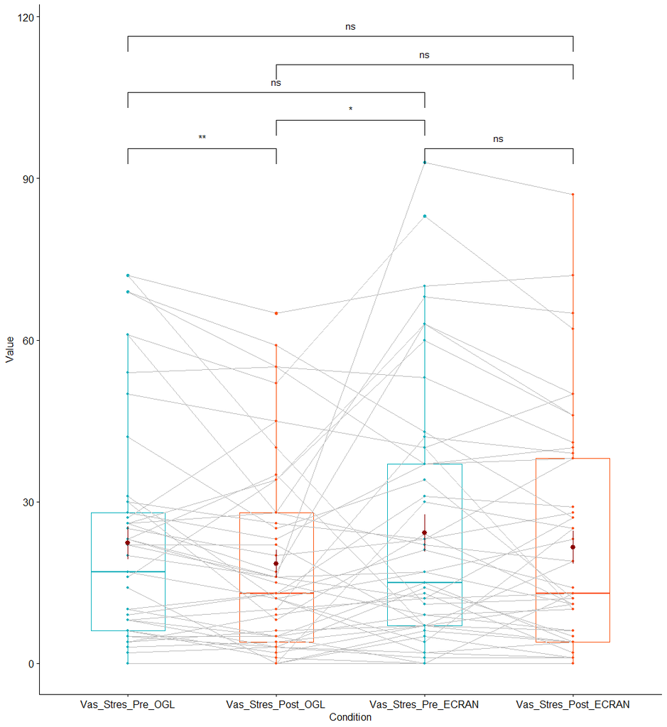

```r
func_ancova_multibox(Data_merged_wide_all,  "ID", "Vas_Bine_Pre_OGL", "Vas_Bine_Post_OGL", "Vas_Bine_Pre_ECRAN", "Vas_Bine_Post_ECRAN")        # ns
```

#### 4.2.0.9 Vas_Bine_Pre_OGL Vas_Bine_Post_OGL Vas_Bine_Pre_ECRAN Vas_Bine_Post_ECRAN

#### 4.2.0.10 Descriptives

| item | group1 | group2 | vars | n | mean | sd | median | trimmed | mad | min | max | range | skew | kurtosis | se |
| --- | --- | --- | --- | --- | --- | --- | --- | --- | --- | --- | --- | --- | --- | --- | --- |
| 1 | Post | ECRAN | 1 | 49 | 70.16327 | 20.50645 | 75 | 71.70732 | 20.7564 | 8 | 100 | 92 | -0.7855419 | 0.4040685 | 2.929493 |
| 2 | Pre | ECRAN | 1 | 49 | 67.20408 | 20.51522 | 70 | 68.60976 | 23.7216 | 3 | 100 | 97 | -0.6981886 | 0.3969482 | 2.930745 |
| 3 | Post | OGL | 1 | 49 | 68.69388 | 20.64300 | 70 | 69.51220 | 25.2042 | 10 | 100 | 90 | -0.3961120 | -0.3927185 | 2.949000 |
| 4 | Pre | OGL | 1 | 49 | 65.95918 | 18.74051 | 68 | 66.82927 | 20.7564 | 11 | 100 | 89 | -0.4763103 | -0.1003387 | 2.677215 |

NA

| .y. | group1 | group2 | p | p.adj | p.format | p.signif | method |
| --- | --- | --- | --- | --- | --- | --- | --- |
| value | Vas_Bine_Pre_OGL | Vas_Bine_Post_OGL | 0.12343339 | 0.49 | 0.123 | ns | T-test |
| value | Vas_Bine_Pre_OGL | Vas_Bine_Pre_ECRAN | 0.64639654 | 1.00 | 0.646 | ns | T-test |
| value | Vas_Bine_Pre_OGL | Vas_Bine_Post_ECRAN | 0.07421415 | 0.37 | 0.074 | ns | T-test |
| value | Vas_Bine_Post_OGL | Vas_Bine_Pre_ECRAN | 0.60893404 | 1.00 | 0.609 | ns | T-test |
| value | Vas_Bine_Post_OGL | Vas_Bine_Post_ECRAN | 0.54181595 | 1.00 | 0.542 | ns | T-test |
| value | Vas_Bine_Pre_ECRAN | Vas_Bine_Post_ECRAN | 0.02256027 | 0.14 | 0.023 | * | T-test |

#### 4.2.0.11 t Change

| estimate | statistic | p.value | parameter | conf.low | conf.high | method | alternative |
| --- | --- | --- | --- | --- | --- | --- | --- |
| -0.2244898 | -0.1132085 | 0.9103375 | 48 | -4.211533 | 3.762553 | Paired t-test | two.sided |

#### 4.2.0.12 ANCOVA Post

##### 4.2.0.12.1 Homogeneity test

| F | df1 | df2 | p |
| --- | --- | --- | --- |
| 0.2410474 | 1 | 96 | 0.6245711 |

##### 4.2.0.12.2 ANCOVA output

| name | ss | df | ms | F | p | etaSq | etaSqP |
| --- | --- | --- | --- | --- | --- | --- | --- |
| Pre | 30135.371900 | 1 | 30135.371900 | 272.55653869 | 0.00000000000000000000000000001159568 | 0.74148265455 | 0.7415363624 |
| OglEcran | 2.943616 | 1 | 2.943616 | 0.02662326 | 0.87073404980200808100931908484199084 | 0.00007242786 | 0.0002801663 |
| Residuals | 10503.730141 | 95 | 110.565580 | NA | NA | NA | NA |

##### 4.2.0.12.3 Post Hoc

| OglEcran1 | sep | OglEcran2 | md | se | df | t | ptukey |
| --- | --- | --- | --- | --- | --- | --- | --- |
| ECRAN | - | OGL | 0.3468007 | 2.125442 | 95 | 0.1631664 | 0.870734 |

##### 4.2.0.12.4 Homogeneity of regression slopes

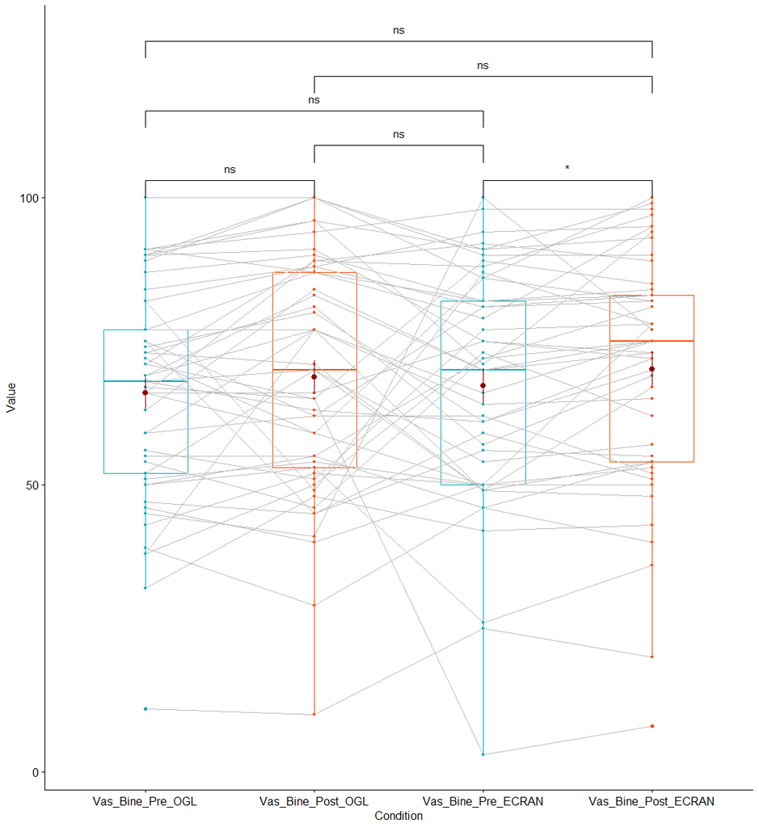

```r
func_ancova_multibox(Data_merged_wide_all,  "ID", "IOS_Pre_OGL", "IOS_Post_OGL", "IOS_Pre_ECRAN", "IOS_Post_ECRAN")                            # sig
```

#### 4.2.0.13 IOS_Pre_OGL IOS_Post_OGL IOS_Pre_ECRAN IOS_Post_ECRAN

#### 4.2.0.14 Descriptives

| item | group1 | group2 | vars | n | mean | sd | median | trimmed | mad | min | max | range | skew | kurtosis | se |
| --- | --- | --- | --- | --- | --- | --- | --- | --- | --- | --- | --- | --- | --- | --- | --- |
| 1 | Post | ECRAN | 1 | 35 | 2.428571 | 1.595687 | 2 | 2.172414 | 1.4826 | 1 | 7 | 6 | 1.2442610 | 0.8300599 | 0.2697204 |
| 2 | Pre | ECRAN | 1 | 35 | 2.428571 | 1.399280 | 2 | 2.275862 | 1.4826 | 1 | 6 | 5 | 0.7993703 | -0.3241089 | 0.2365214 |
| 3 | Post | OGL | 1 | 35 | 3.257143 | 1.754706 | 3 | 3.137931 | 1.4826 | 1 | 7 | 6 | 0.5375455 | -0.7674859 | 0.2965994 |
| 4 | Pre | OGL | 1 | 35 | 2.400000 | 1.397477 | 2 | 2.172414 | 1.4826 | 1 | 6 | 5 | 1.2989726 | 1.1413964 | 0.2362167 |

NA

| .y. | group1 | group2 | p | p.adj | p.format | p.signif | method |
| --- | --- | --- | --- | --- | --- | --- | --- |
| value | IOS_Pre_OGL | IOS_Post_OGL | 0.0001985726 | 0.0012 | 0.0002 | *** | T-test |
| value | IOS_Pre_OGL | IOS_Pre_ECRAN | 0.9062287524 | 1.0000 | 0.9062 | ns | T-test |
| value | IOS_Pre_OGL | IOS_Post_ECRAN | 0.9112132047 | 1.0000 | 0.9112 | ns | T-test |
| value | IOS_Post_OGL | IOS_Pre_ECRAN | 0.0216446740 | 0.1100 | 0.0216 | * | T-test |
| value | IOS_Post_OGL | IOS_Post_ECRAN | 0.0251870423 | 0.1100 | 0.0252 | * | T-test |
| value | IOS_Pre_ECRAN | IOS_Post_ECRAN | 1.0000000000 | 1.0000 | 1.0000 | ns | T-test |

#### 4.2.0.15 t Change

| estimate | statistic | p.value | parameter | conf.low | conf.high | method | alternative |
| --- | --- | --- | --- | --- | --- | --- | --- |
| 0.8571429 | 3.746558 | 0.000665212 | 34 | 0.3922031 | 1.322083 | Paired t-test | two.sided |

#### 4.2.0.16 ANCOVA Post

##### 4.2.0.16.1 Homogeneity test

| F | df1 | df2 | p |
| --- | --- | --- | --- |
| 1.241071 | 1 | 68 | 0.2691869 |

##### 4.2.0.16.2 ANCOVA output

| name | ss | df | ms | F | p | etaSq | etaSqP |
| --- | --- | --- | --- | --- | --- | --- | --- |
| Pre | 129.00151 | 1 | 129.0015102 | 138.8324 | 0.000000000000000005502993 | 0.63205046 | 0.6744925 |
| OglEcran | 12.84287 | 1 | 12.8428742 | 13.8216 | 0.000412654891984006496741 | 0.06292442 | 0.1710137 |
| Residuals | 62.25563 | 67 | 0.9291885 | NA | NA | NA | NA |

##### 4.2.0.16.3 Post Hoc

| OglEcran1 | sep | OglEcran2 | md | se | df | t | ptukey |
| --- | --- | --- | --- | --- | --- | --- | --- |
| ECRAN | - | OGL | -0.8567131 | 0.2304391 | 67 | -3.717742 | 0.0004126549 |

##### 4.2.0.16.4 Homogeneity of regression slopes

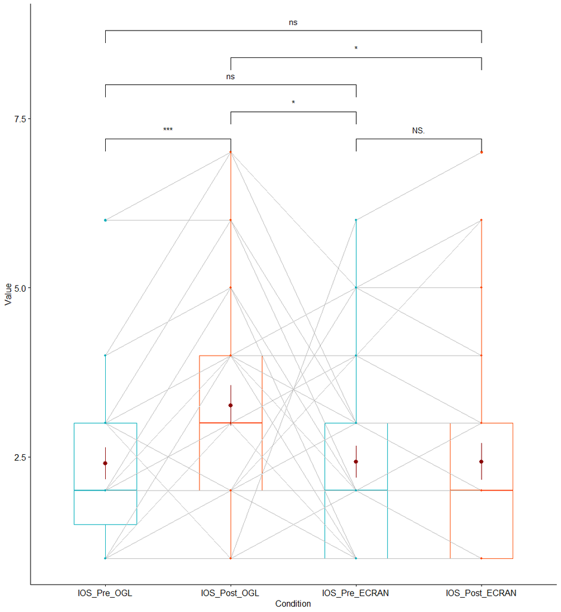

## 4.3 Simple before-after analyses with t test by Gender

```r
# Females
cat("### Fem")
```

### 4.3.1 Fem

```r
func_t_box(Data_fem, "ID", "OXT_Pre_OGL", "OXT_Post_OGL")    # sig
```

#### 4.3.1.1 OXT_Pre_OGL OXT_Post_OGL

| .y. | group1 | group2 | p | p.adj | p.format | p.signif | method |
| --- | --- | --- | --- | --- | --- | --- | --- |
| value | OXT_Pre_OGL | OXT_Post_OGL | 0.03386814 | 0.034 | 0.034 | * | T-test |

| estimate | statistic | p.value | parameter | conf.low | conf.high | method | alternative |
| --- | --- | --- | --- | --- | --- | --- | --- |
| -0.1663468 | -2.25621 | 0.03386814 | 23 | -0.3188656 | -0.01382797 | Paired t-test | two.sided |

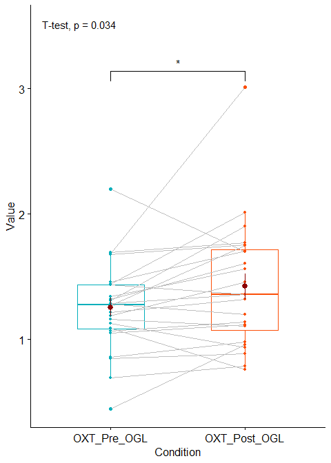

```r
func_t_box(Data_fem, "ID", "OXT_Pre_ECRAN", "OXT_Post_ECRAN")   # ns
```

#### 4.3.1.2 OXT_Pre_ECRAN OXT_Post_ECRAN

| .y. | group1 | group2 | p | p.adj | p.format | p.signif | method |
| --- | --- | --- | --- | --- | --- | --- | --- |
| value | OXT_Pre_ECRAN | OXT_Post_ECRAN | 0.3596285 | 0.36 | 0.36 | ns | T-test |

| estimate | statistic | p.value | parameter | conf.low | conf.high | method | alternative |
| --- | --- | --- | --- | --- | --- | --- | --- |
| -0.0580831 | -0.9347492 | 0.3596285 | 23 | -0.1866246 | 0.07045839 | Paired t-test | two.sided |

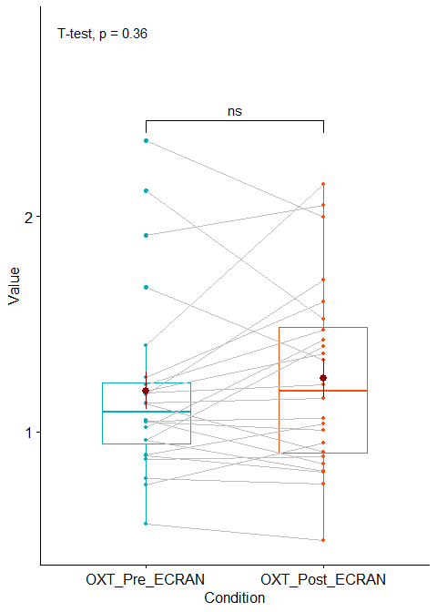

```r
func_t_box(Data_fem, "ID", "Vas_Stres_Pre_OGL", "Vas_Stres_Post_OGL")         # sig
```

#### 4.3.1.3 Vas_Stres_Pre_OGL Vas_Stres_Post_OGL

| .y. | group1 | group2 | p | p.adj | p.format | p.signif | method |
| --- | --- | --- | --- | --- | --- | --- | --- |
| value | Vas_Stres_Pre_OGL | Vas_Stres_Post_OGL | 0.007596313 | 0.0076 | 0.0076 | ** | T-test |

| estimate | statistic | p.value | parameter | conf.low | conf.high | method | alternative |
| --- | --- | --- | --- | --- | --- | --- | --- |
| 6.185185 | 2.89424 | 0.007596313 | 26 | 1.79238 | 10.57799 | Paired t-test | two.sided |

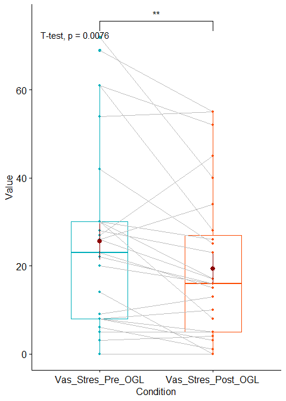

```r
func_t_box(Data_fem, "ID", "Vas_Stres_Pre_ECRAN", "Vas_Stres_Post_ECRAN")     # sig
```

#### 4.3.1.4 Vas_Stres_Pre_ECRAN Vas_Stres_Post_ECRAN

| .y. | group1 | group2 | p | p.adj | p.format | p.signif | method |
| --- | --- | --- | --- | --- | --- | --- | --- |
| value | Vas_Stres_Pre_ECRAN | Vas_Stres_Post_ECRAN | 0.02037067 | 0.02 | 0.02 | * | T-test |

| estimate | statistic | p.value | parameter | conf.low | conf.high | method | alternative |
| --- | --- | --- | --- | --- | --- | --- | --- |
| 4.923077 | 2.476902 | 0.02037067 | 25 | 0.8295491 | 9.016605 | Paired t-test | two.sided |

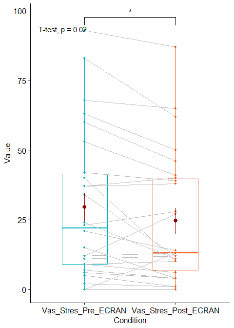

```r
func_t_box(Data_fem, "ID", "Vas_Bine_Pre_OGL", "Vas_Bine_Post_OGL")           # ns
```

#### 4.3.1.5 Vas_Bine_Pre_OGL Vas_Bine_Post_OGL

| .y. | group1 | group2 | p | p.adj | p.format | p.signif | method |
| --- | --- | --- | --- | --- | --- | --- | --- |
| value | Vas_Bine_Pre_OGL | Vas_Bine_Post_OGL | 0.2121913 | 0.21 | 0.21 | ns | T-test |

| estimate | statistic | p.value | parameter | conf.low | conf.high | method | alternative |
| --- | --- | --- | --- | --- | --- | --- | --- |
| -2.814815 | -1.279011 | 0.2121913 | 26 | -7.338573 | 1.708943 | Paired t-test | two.sided |

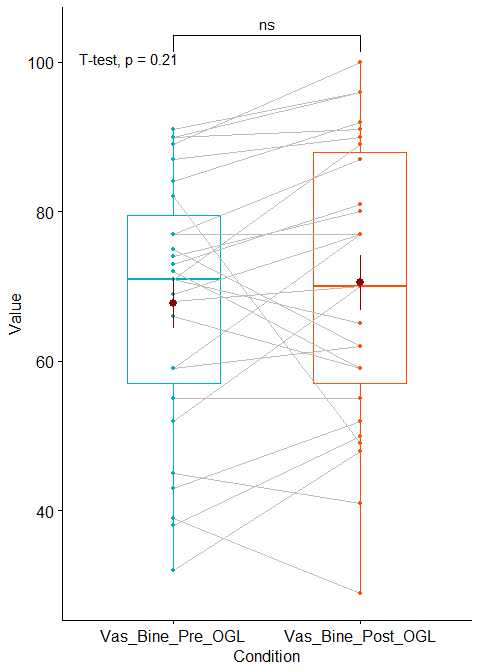

```r
func_t_box(Data_fem, "ID", "Vas_Bine_Pre_ECRAN", "Vas_Bine_Post_ECRAN")       # ns
```

#### 4.3.1.6 Vas_Bine_Pre_ECRAN Vas_Bine_Post_ECRAN

| .y. | group1 | group2 | p | p.adj | p.format | p.signif | method |
| --- | --- | --- | --- | --- | --- | --- | --- |
| value | Vas_Bine_Pre_ECRAN | Vas_Bine_Post_ECRAN | 0.1161065 | 0.12 | 0.12 | ns | T-test |

| estimate | statistic | p.value | parameter | conf.low | conf.high | method | alternative |
| --- | --- | --- | --- | --- | --- | --- | --- |
| -3.384615 | -1.6278 | 0.1161065 | 25 | -7.666927 | 0.8976965 | Paired t-test | two.sided |

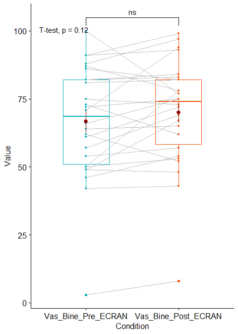

```r
func_t_box(Data_fem, "ID", "IOS_Pre_OGL", "IOS_Post_OGL")                     # sig
```

#### 4.3.1.7 IOS_Pre_OGL IOS_Post_OGL

| .y. | group1 | group2 | p | p.adj | p.format | p.signif | method |
| --- | --- | --- | --- | --- | --- | --- | --- |
| value | IOS_Pre_OGL | IOS_Post_OGL | 0.00002962643 | 0.00003 | 0.00003 | **** | T-test |

| estimate | statistic | p.value | parameter | conf.low | conf.high | method | alternative |
| --- | --- | --- | --- | --- | --- | --- | --- |
| -0.7777778 | -5.047772 | 0.00002962643 | 26 | -1.094501 | -0.4610548 | Paired t-test | two.sided |

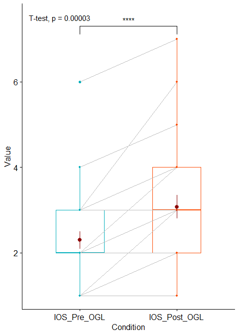

```r
func_t_box(Data_fem, "ID", "IOS_Pre_ECRAN", "IOS_Post_ECRAN")                 # ns
```

#### 4.3.1.8 IOS_Pre_ECRAN IOS_Post_ECRAN

| .y. | group1 | group2 | p | p.adj | p.format | p.signif | method |
| --- | --- | --- | --- | --- | --- | --- | --- |
| value | IOS_Pre_ECRAN | IOS_Post_ECRAN | 0.3305649 | 0.33 | 0.33 | ns | T-test |

| estimate | statistic | p.value | parameter | conf.low | conf.high | method | alternative |
| --- | --- | --- | --- | --- | --- | --- | --- |
| 0.1052632 | 1 | 0.3305649 | 18 | -0.1158865 | 0.3264128 | Paired t-test | two.sided |

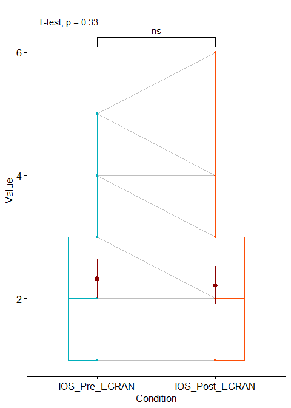

```r
# Males
cat("### Masc")
```

### 4.3.2 Masc

```r
func_t_box(Data_masc, "ID", "OXT_Pre_OGL", "OXT_Post_OGL")    # ns
```

#### 4.3.2.1 OXT_Pre_OGL OXT_Post_OGL

| .y. | group1 | group2 | p | p.adj | p.format | p.signif | method |
| --- | --- | --- | --- | --- | --- | --- | --- |
| value | OXT_Pre_OGL | OXT_Post_OGL | 0.3026794 | 0.3 | 0.3 | ns | T-test |

| estimate | statistic | p.value | parameter | conf.low | conf.high | method | alternative |
| --- | --- | --- | --- | --- | --- | --- | --- |
| 0.06540779 | 1.056643 | 0.3026794 | 21 | -0.06332348 | 0.1941391 | Paired t-test | two.sided |

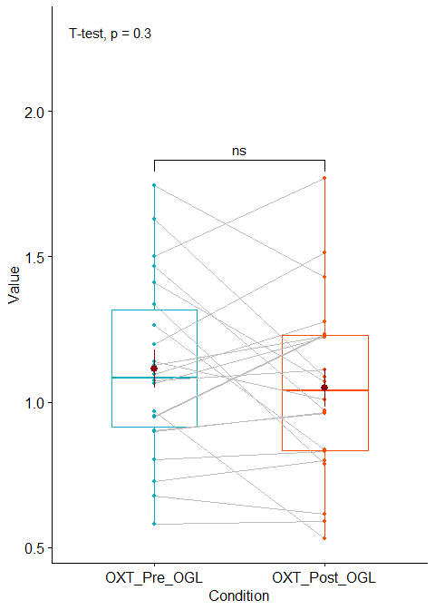

```r
func_t_box(Data_masc, "ID", "OXT_Pre_ECRAN", "OXT_Post_ECRAN")   # ns
```

#### 4.3.2.2 OXT_Pre_ECRAN OXT_Post_ECRAN

| .y. | group1 | group2 | p | p.adj | p.format | p.signif | method |
| --- | --- | --- | --- | --- | --- | --- | --- |
| value | OXT_Pre_ECRAN | OXT_Post_ECRAN | 0.157069 | 0.16 | 0.16 | ns | T-test |

| estimate | statistic | p.value | parameter | conf.low | conf.high | method | alternative |
| --- | --- | --- | --- | --- | --- | --- | --- |
| -0.08996274 | -1.46746 | 0.157069 | 21 | -0.2174536 | 0.0375281 | Paired t-test | two.sided |

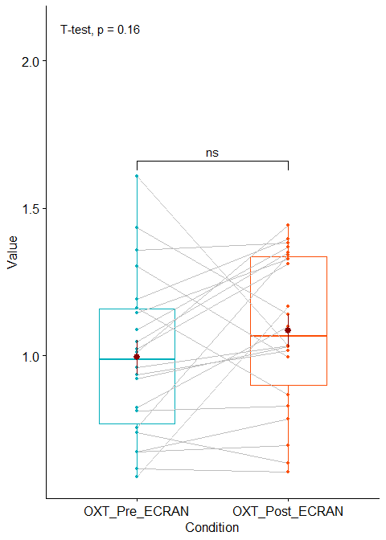

```r
func_t_box(Data_masc, "ID", "Vas_Stres_Pre_OGL", "Vas_Stres_Post_OGL")         # ns
```

#### 4.3.2.3 Vas_Stres_Pre_OGL Vas_Stres_Post_OGL

| .y. | group1 | group2 | p | p.adj | p.format | p.signif | method |
| --- | --- | --- | --- | --- | --- | --- | --- |
| value | Vas_Stres_Pre_OGL | Vas_Stres_Post_OGL | 0.385645 | 0.39 | 0.39 | ns | T-test |

| estimate | statistic | p.value | parameter | conf.low | conf.high | method | alternative |
| --- | --- | --- | --- | --- | --- | --- | --- |
| 1.347826 | 0.8851561 | 0.385645 | 22 | -1.810058 | 4.50571 | Paired t-test | two.sided |

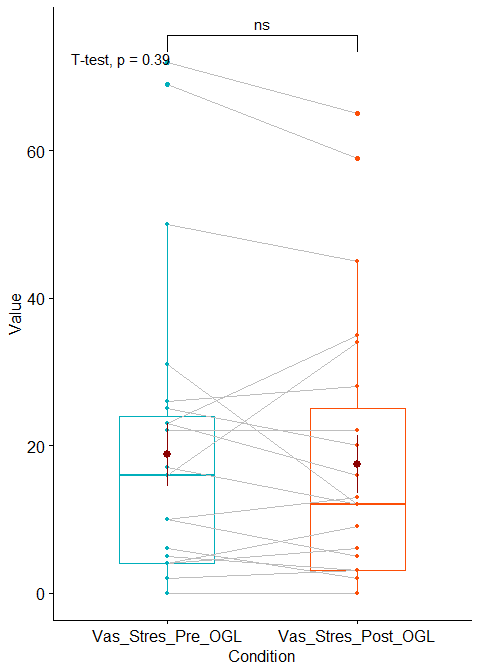

```r
func_t_box(Data_masc, "ID", "Vas_Stres_Pre_ECRAN", "Vas_Stres_Post_ECRAN")     # ns
```

#### 4.3.2.4 Vas_Stres_Pre_ECRAN Vas_Stres_Post_ECRAN

| .y. | group1 | group2 | p | p.adj | p.format | p.signif | method |
| --- | --- | --- | --- | --- | --- | --- | --- |
| value | Vas_Stres_Pre_ECRAN | Vas_Stres_Post_ECRAN | 0.9818213 | 0.98 | 0.98 | ns | T-test |

| estimate | statistic | p.value | parameter | conf.low | conf.high | method | alternative |
| --- | --- | --- | --- | --- | --- | --- | --- |
| 0.04347826 | 0.02304601 | 0.9818213 | 22 | -3.869059 | 3.956016 | Paired t-test | two.sided |

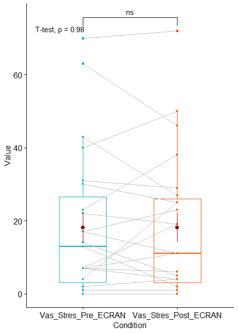

```r
func_t_box(Data_masc, "ID", "Vas_Bine_Pre_OGL", "Vas_Bine_Post_OGL")           # ns
```

#### 4.3.2.5 Vas_Bine_Pre_OGL Vas_Bine_Post_OGL

| .y. | group1 | group2 | p | p.adj | p.format | p.signif | method |
| --- | --- | --- | --- | --- | --- | --- | --- |
| value | Vas_Bine_Pre_OGL | Vas_Bine_Post_OGL | 0.3052018 | 0.31 | 0.31 | ns | T-test |

| estimate | statistic | p.value | parameter | conf.low | conf.high | method | alternative |
| --- | --- | --- | --- | --- | --- | --- | --- |
| -2.869565 | -1.049809 | 0.3052018 | 22 | -8.538321 | 2.799191 | Paired t-test | two.sided |

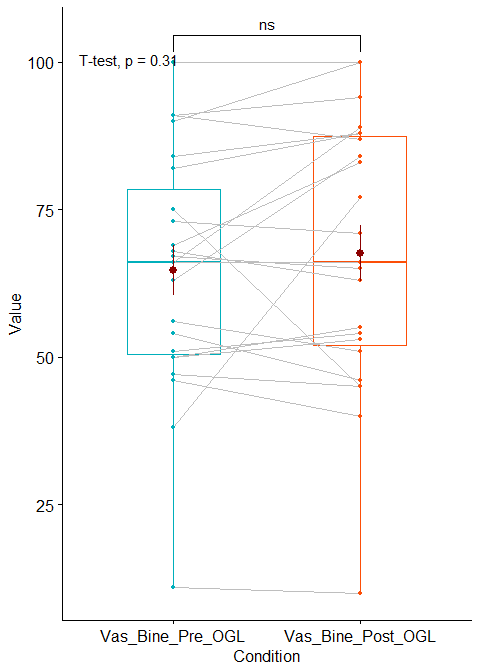

```r
func_t_box(Data_masc, "ID", "Vas_Bine_Pre_ECRAN", "Vas_Bine_Post_ECRAN")       # ns
```

#### 4.3.2.6 Vas_Bine_Pre_ECRAN Vas_Bine_Post_ECRAN

| .y. | group1 | group2 | p | p.adj | p.format | p.signif | method |
| --- | --- | --- | --- | --- | --- | --- | --- |
| value | Vas_Bine_Pre_ECRAN | Vas_Bine_Post_ECRAN | 0.07470194 | 0.075 | 0.075 | ns | T-test |

| estimate | statistic | p.value | parameter | conf.low | conf.high | method | alternative |
| --- | --- | --- | --- | --- | --- | --- | --- |
| -2.478261 | -1.871025 | 0.07470194 | 22 | -5.225204 | 0.2686818 | Paired t-test | two.sided |

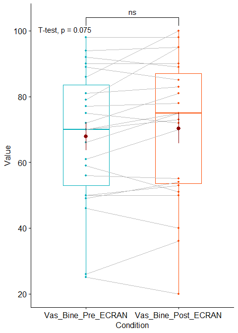

```r
func_t_box(Data_masc, "ID", "IOS_Pre_OGL", "IOS_Post_OGL")                     # sig
```

#### 4.3.2.7 IOS_Pre_OGL IOS_Post_OGL

| .y. | group1 | group2 | p | p.adj | p.format | p.signif | method |
| --- | --- | --- | --- | --- | --- | --- | --- |
| value | IOS_Pre_OGL | IOS_Post_OGL | 0.004758559 | 0.0048 | 0.0048 | ** | T-test |

| estimate | statistic | p.value | parameter | conf.low | conf.high | method | alternative |
| --- | --- | --- | --- | --- | --- | --- | --- |
| -0.9565217 | -3.139946 | 0.004758559 | 22 | -1.588286 | -0.3247577 | Paired t-test | two.sided |

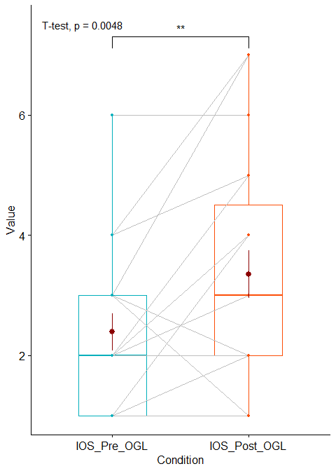

```r
func_t_box(Data_masc, "ID", "IOS_Pre_ECRAN", "IOS_Post_ECRAN")                 # ns
```

#### 4.3.2.8 IOS_Pre_ECRAN IOS_Post_ECRAN

| .y. | group1 | group2 | p | p.adj | p.format | p.signif | method |
| --- | --- | --- | --- | --- | --- | --- | --- |
| value | IOS_Pre_ECRAN | IOS_Post_ECRAN | 0.4973105 | 0.5 | 0.5 | ns | T-test |

| estimate | statistic | p.value | parameter | conf.low | conf.high | method | alternative |
| --- | --- | --- | --- | --- | --- | --- | --- |
| -0.125 | -0.6956083 | 0.4973105 | 15 | -0.508019 | 0.258019 | Paired t-test | two.sided |

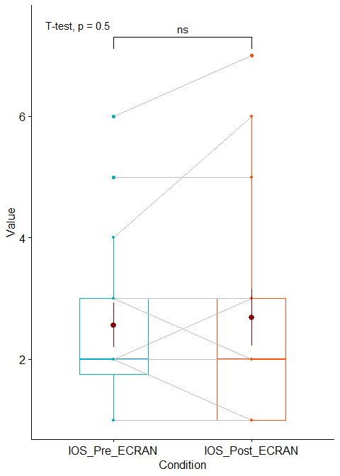

## 4.4 tChance and ANCOVAPost by Gender

```r
# Females
cat("### Fem")
```

### 4.4.1 Fem

```r
Data_fem %>%
  func_ancova_multibox("ID", "OXT_Pre_OGL", "OXT_Post_OGL", "OXT_Pre_ECRAN", "OXT_Post_ECRAN")                                    # ns (PROBLEM)
```

#### 4.4.1.1 OXT_Pre_OGL OXT_Post_OGL OXT_Pre_ECRAN OXT_Post_ECRAN

#### 4.4.1.2 Descriptives

| item | group1 | group2 | vars | n | mean | sd | median | trimmed | mad | min | max | range | skew | kurtosis | se |
| --- | --- | --- | --- | --- | --- | --- | --- | --- | --- | --- | --- | --- | --- | --- | --- |
| 1 | Post | ECRAN | 1 | 24 | 1.248651 | 0.4356792 | 1.187171 | 1.225721 | 0.4369985 | 0.4974490 | 2.146657 | 1.649208 | 0.4647219 | -0.7333406 | 0.08893265 |
| 2 | Pre | ECRAN | 1 | 24 | 1.190568 | 0.4292976 | 1.090677 | 1.138732 | 0.2169568 | 0.5716175 | 2.352502 | 1.780884 | 1.2392802 | 0.8508425 | 0.08763001 |
| 3 | Post | OGL | 1 | 24 | 1.422698 | 0.5004102 | 1.360143 | 1.378796 | 0.5392363 | 0.7591795 | 3.009259 | 2.250080 | 1.1230756 | 1.7633577 | 0.10214581 |
| 4 | Pre | OGL | 1 | 24 | 1.256352 | 0.3603030 | 1.275411 | 1.255572 | 0.2561784 | 0.4504145 | 2.198205 | 1.747790 | 0.2166790 | 0.6350227 | 0.07354654 |

NA

| .y. | group1 | group2 | p | p.adj | p.format | p.signif | method |
| --- | --- | --- | --- | --- | --- | --- | --- |
| value | OXT_Pre_OGL | OXT_Post_OGL | 0.03386814 | 0.20 | 0.034 | * | T-test |
| value | OXT_Pre_OGL | OXT_Pre_ECRAN | 0.48564457 | 1.00 | 0.486 | ns | T-test |
| value | OXT_Pre_OGL | OXT_Post_ECRAN | 0.93101047 | 1.00 | 0.931 | ns | T-test |
| value | OXT_Post_OGL | OXT_Pre_ECRAN | 0.05307646 | 0.27 | 0.053 | ns | T-test |
| value | OXT_Post_OGL | OXT_Post_ECRAN | 0.11304203 | 0.45 | 0.113 | ns | T-test |
| value | OXT_Pre_ECRAN | OXT_Post_ECRAN | 0.35962855 | 1.00 | 0.360 | ns | T-test |

#### 4.4.1.3 t Change

| estimate | statistic | p.value | parameter | conf.low | conf.high | method | alternative |
| --- | --- | --- | --- | --- | --- | --- | --- |
| 0.1082637 | 1.183033 | 0.2488809 | 23 | -0.08104676 | 0.2975741 | Paired t-test | two.sided |

#### 4.4.1.4 ANCOVA Post

##### 4.4.1.4.1 Homogeneity test

| F | df1 | df2 | p |
| --- | --- | --- | --- |
| 0.09535605 | 1 | 46 | 0.7588696 |

##### 4.4.1.4.2 ANCOVA output

| name | ss | df | ms | F | p | etaSq | etaSqP |
| --- | --- | --- | --- | --- | --- | --- | --- |
| Pre | 5.1655815 | 1 | 5.1655815 | 46.868608 | 0.00000001724283 | 0.50188789 | 0.51017001 |
| OglEcran | 0.1670856 | 1 | 0.1670856 | 1.516009 | 0.22462075326682 | 0.01623403 | 0.03259112 |
| Residuals | 4.9596345 | 45 | 0.1102141 | NA | NA | NA | NA |

##### 4.4.1.4.3 Post Hoc

| OglEcran1 | sep | OglEcran2 | md | se | df | t | ptukey |
| --- | --- | --- | --- | --- | --- | --- | --- |
| ECRAN | - | OGL | -0.1184225 | 0.09617966 | 45 | -1.231263 | 0.2246208 |

##### 4.4.1.4.4 Homogeneity of regression slopes

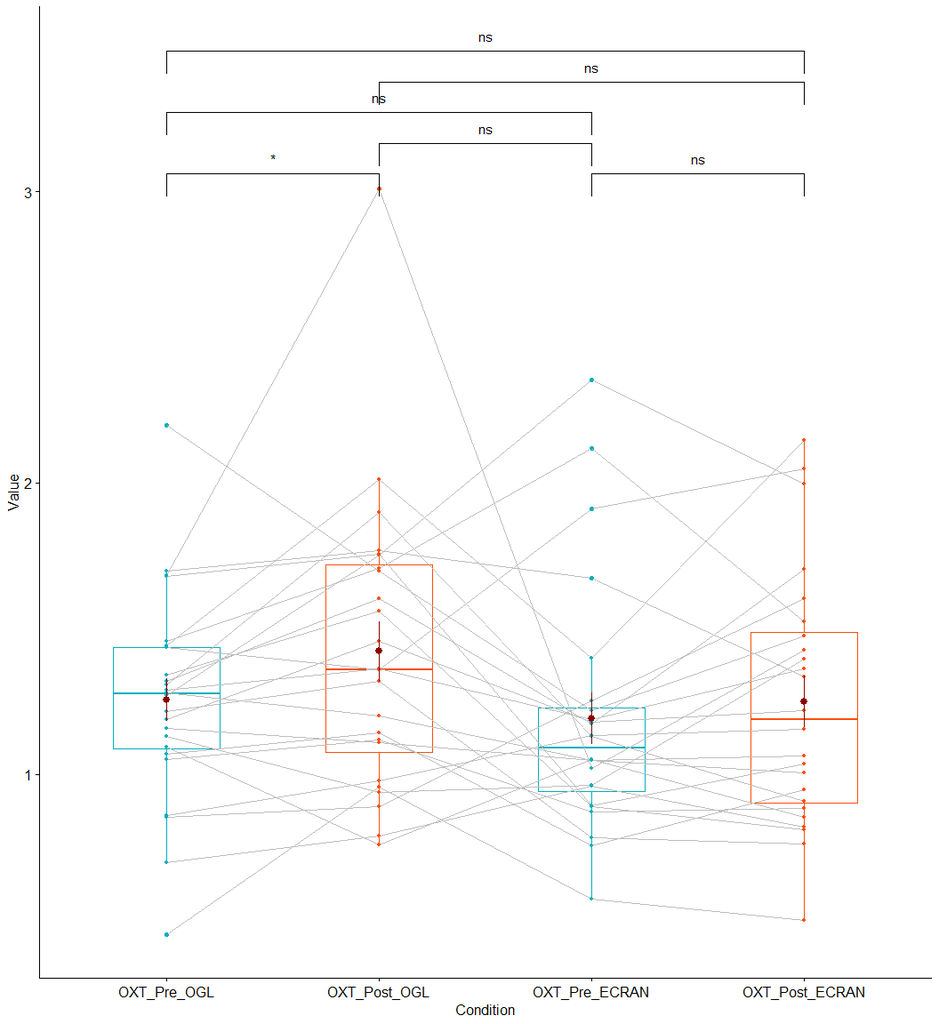

```r
func_ancova_multibox(Data_fem, "ID", "Vas_Stres_Pre_OGL", "Vas_Stres_Post_OGL", "Vas_Stres_Pre_ECRAN", "Vas_Stres_Post_ECRAN")    # ns
```

#### 4.4.1.5 Vas_Stres_Pre_OGL Vas_Stres_Post_OGL Vas_Stres_Pre_ECRAN Vas_Stres_Post_ECRAN

#### 4.4.1.6 Descriptives

| item | group1 | group2 | vars | n | mean | sd | median | trimmed | mad | min | max | range | skew | kurtosis | se |
| --- | --- | --- | --- | --- | --- | --- | --- | --- | --- | --- | --- | --- | --- | --- | --- |
| 1 | Post | ECRAN | 1 | 26 | 24.53846 | 23.31220 | 13.0 | 22.04545 | 17.7912 | 0 | 87 | 87 | 0.9488133 | -0.06221696 | 4.571898 |
| 2 | Pre | ECRAN | 1 | 26 | 29.46154 | 26.59809 | 22.0 | 26.81818 | 22.9803 | 0 | 93 | 93 | 0.8210161 | -0.47162875 | 5.216315 |
| 3 | Post | OGL | 1 | 26 | 19.46154 | 17.70476 | 15.5 | 18.00000 | 16.3086 | 0 | 55 | 55 | 0.7447446 | -0.74225752 | 3.472189 |
| 4 | Pre | OGL | 1 | 26 | 25.38462 | 21.90356 | 22.5 | 23.59091 | 21.4977 | 0 | 72 | 72 | 0.7908224 | -0.63442998 | 4.295642 |

NA

| .y. | group1 | group2 | p | p.adj | p.format | p.signif | method |
| --- | --- | --- | --- | --- | --- | --- | --- |
| value | Vas_Stres_Pre_OGL | Vas_Stres_Post_OGL | 0.01262498 | 0.076 | 0.013 | * | T-test |
| value | Vas_Stres_Pre_OGL | Vas_Stres_Pre_ECRAN | 0.39054244 | 0.780 | 0.391 | ns | T-test |
| value | Vas_Stres_Pre_OGL | Vas_Stres_Post_ECRAN | 0.85322928 | 0.850 | 0.853 | ns | T-test |
| value | Vas_Stres_Post_OGL | Vas_Stres_Pre_ECRAN | 0.02685435 | 0.110 | 0.027 | * | T-test |
| value | Vas_Stres_Post_OGL | Vas_Stres_Post_ECRAN | 0.23613256 | 0.710 | 0.236 | ns | T-test |
| value | Vas_Stres_Pre_ECRAN | Vas_Stres_Post_ECRAN | 0.02037067 | 0.100 | 0.020 | * | T-test |

#### 4.4.1.7 t Change

| estimate | statistic | p.value | parameter | conf.low | conf.high | method | alternative |
| --- | --- | --- | --- | --- | --- | --- | --- |
| -1 | -0.3244166 | 0.7483216 | 25 | -7.348438 | 5.348438 | Paired t-test | two.sided |

#### 4.4.1.8 ANCOVA Post

##### 4.4.1.8.1 Homogeneity test

| F | df1 | df2 | p |
| --- | --- | --- | --- |
| 2.634633 | 1 | 50 | 0.1108452 |

##### 4.4.1.8.2 ANCOVA output

| name | ss | df | ms | F | p | etaSq | etaSqP |
| --- | --- | --- | --- | --- | --- | --- | --- |
| Pre | 17344.22362 | 1 | 17344.22362 | 208.3671440 | 0.0000000000000000002816828 | 0.80774040 | 0.80961051 |
| OglEcran | 49.59895 | 1 | 49.59895 | 0.5958636 | 0.4438676985392496776583471 | 0.00230988 | 0.01201438 |
| Residuals | 4078.69946 | 49 | 83.23876 | NA | NA | NA | NA |

##### 4.4.1.8.3 Post Hoc

| OglEcran1 | sep | OglEcran2 | md | se | df | t | ptukey |
| --- | --- | --- | --- | --- | --- | --- | --- |
| ECRAN | - | OGL | 1.960377 | 2.539605 | 49 | 0.771922 | 0.4438677 |

##### 4.4.1.8.4 Homogeneity of regression slopes

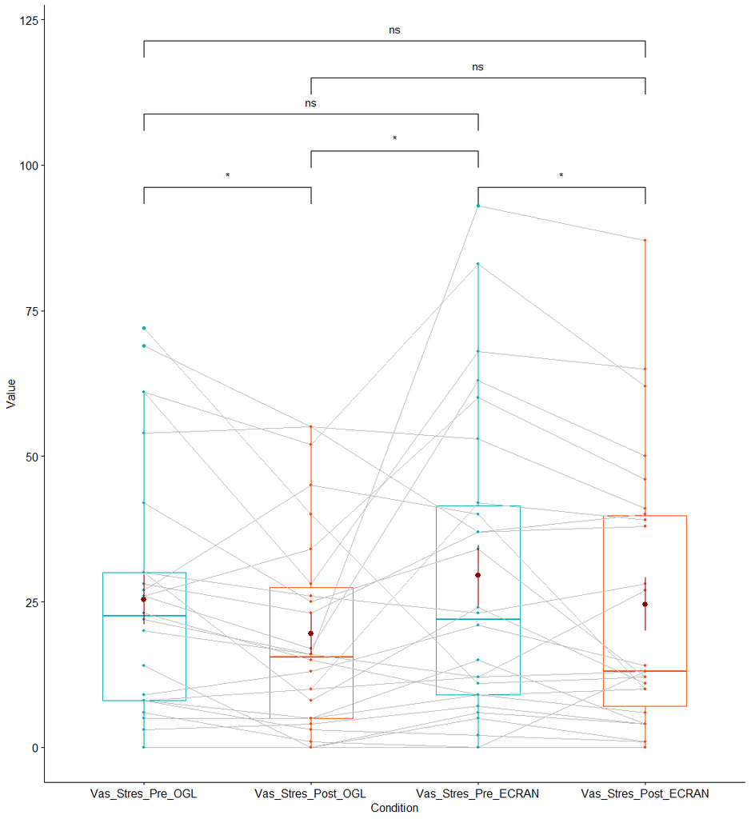

```r
func_ancova_multibox(Data_fem, "ID", "Vas_Bine_Pre_OGL", "Vas_Bine_Post_OGL", "Vas_Bine_Pre_ECRAN", "Vas_Bine_Post_ECRAN")        # ns
```